```python
import numpy as np # linear algebra
import pandas as pd # data processing, CSV file I/O (e.g. pd.read_csv)
import matplotlib.pyplot as plt #Cuz why not
import seaborn as sns #Not using it now
import sklearn as sr # linear algebra
```

```python
df_data = pd.read_csv('2019-Dec.csv')
df_data.head(50)
```

|  | event_time | event_type | product_id | category_id | category_code | brand | price | user_id | user_session |
| --- | --- | --- | --- | --- | --- | --- | --- | --- | --- |
| 0 | 2019-12-01 00:00:00 UTC | remove_from_cart | 5712790 | 1487580005268456287 | NaN | f.o.x | 6.27 | 576802932 | 51d85cb0-897f-48d2-918b-ad63965c12dc |
| 1 | 2019-12-01 00:00:00 UTC | view | 5764655 | 1487580005411062629 | NaN | cnd | 29.05 | 412120092 | 8adff31e-2051-4894-9758-224bfa8aec18 |
| 2 | 2019-12-01 00:00:02 UTC | cart | 4958 | 1487580009471148064 | NaN | runail | 1.19 | 494077766 | c99a50e8-2fac-4c4d-89ec-41c05f114554 |
| 3 | 2019-12-01 00:00:05 UTC | view | 5848413 | 1487580007675986893 | NaN | freedecor | 0.79 | 348405118 | 722ffea5-73c0-4924-8e8f-371ff8031af4 |
| 4 | 2019-12-01 00:00:07 UTC | view | 5824148 | 1487580005511725929 | NaN | NaN | 5.56 | 576005683 | 28172809-7e4a-45ce-bab0-5efa90117cd5 |
| 5 | 2019-12-01 00:00:09 UTC | view | 5773361 | 1487580005134238553 | NaN | runail | 2.62 | 560109803 | 38cf4ba1-4a0a-4c9e-b870-46685d105f95 |
| 6 | 2019-12-01 00:00:18 UTC | cart | 5629988 | 1487580009311764506 | NaN | NaN | 1.19 | 579966747 | 1512be50-d0fd-4a92-bcd8-3ea3943f2a3b |
| 7 | 2019-12-01 00:00:22 UTC | view | 5807805 | 1487580005713052531 | NaN | ingarden | 4.44 | 576005683 | 28172809-7e4a-45ce-bab0-5efa90117cd5 |
| 8 | 2019-12-01 00:00:27 UTC | view | 5588608 | 1487580008145748965 | NaN | roubloff | 5.40 | 546170008 | 676d9fcc-2a4f-4448-b49d-136f2e4208c1 |
| 9 | 2019-12-01 00:00:34 UTC | cart | 5335 | 1487580009605365797 | NaN | runail | 0.40 | 494077766 | c99a50e8-2fac-4c4d-89ec-41c05f114554 |
| 10 | 2019-12-01 00:00:40 UTC | cart | 5755170 | 1487580009387261981 | NaN | NaN | 2.79 | 579751441 | 8de492d7-0937-47ae-be2c-a7615aec2b0d |
| 11 | 2019-12-01 00:00:44 UTC | remove_from_cart | 5650294 | 1487580007835370453 | NaN | metzger | 3.33 | 576802932 | 51d85cb0-897f-48d2-918b-ad63965c12dc |
| 12 | 2019-12-01 00:00:45 UTC | cart | 5755170 | 1487580009387261981 | NaN | NaN | 2.79 | 579751441 | 8de492d7-0937-47ae-be2c-a7615aec2b0d |
| 13 | 2019-12-01 00:00:46 UTC | remove_from_cart | 5692261 | 1487580007835370453 | NaN | staleks | 6.35 | 576802932 | 51d85cb0-897f-48d2-918b-ad63965c12dc |
| 14 | 2019-12-01 00:00:46 UTC | view | 5798929 | 1783999068909863670 | NaN | zinger | 6.19 | 579966747 | 1512be50-d0fd-4a92-bcd8-3ea3943f2a3b |
| 15 | 2019-12-01 00:00:46 UTC | cart | 5755170 | 1487580009387261981 | NaN | NaN | 2.79 | 579751441 | 8de492d7-0937-47ae-be2c-a7615aec2b0d |
| 16 | 2019-12-01 00:00:49 UTC | remove_from_cart | 5694628 | 1487580007835370453 | NaN | yoko | 3.65 | 576802932 | 51d85cb0-897f-48d2-918b-ad63965c12dc |
| 17 | 2019-12-01 00:00:50 UTC | view | 3936 | 1487580005343953762 | NaN | entity | 10.95 | 579969717 | 006dd2fb-ae1e-4461-985a-d4e70ca64543 |
| 18 | 2019-12-01 00:00:52 UTC | cart | 5761411 | 1487580007432717250 | NaN | ingarden | 2.86 | 494077766 | c99a50e8-2fac-4c4d-89ec-41c05f114554 |
| 19 | 2019-12-01 00:00:58 UTC | cart | 5761411 | 1487580007432717250 | NaN | ingarden | 2.86 | 494077766 | c99a50e8-2fac-4c4d-89ec-41c05f114554 |
| 20 | 2019-12-01 00:00:58 UTC | view | 5817779 | 1487580010872045658 | NaN | irisk | 0.79 | 576802932 | f7257a5b-5449-4136-aa56-e373f484ffa2 |
| 21 | 2019-12-01 00:01:01 UTC | view | 5832416 | 1487580009471148064 | NaN | NaN | 0.95 | 576802932 | 01dbbcc3-b26b-4bed-bce4-1b506725a351 |
| 22 | 2019-12-01 00:01:02 UTC | view | 5706778 | 1487580005268456287 | NaN | beautix | 14.13 | 564257889 | a4248817-8d0d-4dac-96e6-a586563308de |
| 23 | 2019-12-01 00:01:11 UTC | view | 5849033 | 1487580005092295511 | NaN | uno | 10.32 | 562651624 | f8783526-2382-454b-b417-fa48d371030f |
| 24 | 2019-12-01 00:01:15 UTC | cart | 5904369 | 1487580007675986893 | NaN | NaN | 1.59 | 348405118 | 722ffea5-73c0-4924-8e8f-371ff8031af4 |
| 25 | 2019-12-01 00:01:16 UTC | view | 5881896 | 1487580011903844485 | NaN | NaN | 3.63 | 537197314 | 1fc5bdf5-a94f-4e5f-8283-215b3fed14c1 |
| 26 | 2019-12-01 00:01:16 UTC | remove_from_cart | 5742926 | 1487580006317032337 | NaN | yoko | 21.78 | 576802932 | 51d85cb0-897f-48d2-918b-ad63965c12dc |
| 27 | 2019-12-01 00:01:19 UTC | cart | 5600449 | 1487580008145748965 | NaN | roubloff | 15.38 | 546170008 | 676d9fcc-2a4f-4448-b49d-136f2e4208c1 |
| 28 | 2019-12-01 00:01:19 UTC | view | 5614842 | 1487580005411062629 | NaN | cnd | 13.56 | 412120092 | 8adff31e-2051-4894-9758-224bfa8aec18 |
| 29 | 2019-12-01 00:01:22 UTC | cart | 5666749 | 1487580009076883471 | NaN | philips | 3.43 | 494077766 | c99a50e8-2fac-4c4d-89ec-41c05f114554 |
| 30 | 2019-12-01 00:01:22 UTC | view | 5847872 | 1487580006317032337 | NaN | NaN | 7.94 | 576802932 | d3809963-53ce-47fd-88c0-21afda8c90ca |
| 31 | 2019-12-01 00:01:34 UTC | remove_from_cart | 5847872 | 1487580006317032337 | NaN | NaN | 7.94 | 576802932 | 51d85cb0-897f-48d2-918b-ad63965c12dc |
| 32 | 2019-12-01 00:01:44 UTC | cart | 5862564 | 1487580008145748965 | NaN | roubloff | 1.71 | 546170008 | 676d9fcc-2a4f-4448-b49d-136f2e4208c1 |
| 33 | 2019-12-01 00:01:47 UTC | view | 5732026 | 1487580011970953351 | furniture.bathroom.bath | domix | 4.16 | 509445281 | 91e9d610-759a-4831-b89a-22f2ab5fbc0f |
| 34 | 2019-12-01 00:01:50 UTC | view | 5795703 | 1487580005268456287 | NaN | NaN | 10.95 | 556579890 | 1d94a188-7fa5-4c52-a9fc-99abf8b4838f |
| 35 | 2019-12-01 00:01:51 UTC | view | 5859489 | 1487580005671109489 | NaN | masura | 1.73 | 521863546 | 50040a3b-8a81-483d-b0e8-8152821701f8 |
| 36 | 2019-12-01 00:01:52 UTC | cart | 5700046 | 1487580009286598681 | NaN | runail | 0.40 | 576802932 | 51d85cb0-897f-48d2-918b-ad63965c12dc |
| 37 | 2019-12-01 00:01:52 UTC | cart | 5700046 | 1487580009286598681 | NaN | runail | 0.40 | 576802932 | 51d85cb0-897f-48d2-918b-ad63965c12dc |
| 38 | 2019-12-01 00:01:58 UTC | view | 5810157 | 1487580009445982239 | NaN | irisk | 1.43 | 494077766 | c99a50e8-2fac-4c4d-89ec-41c05f114554 |
| 39 | 2019-12-01 00:02:16 UTC | view | 5899850 | 2115334439910245200 | NaN | NaN | 4.46 | 538507783 | 177b9f5a-9ef3-4e11-b31e-6efd86a9bff2 |
| 40 | 2019-12-01 00:02:16 UTC | cart | 5862313 | 1487580007675986893 | NaN | freedecor | 0.79 | 348405118 | 722ffea5-73c0-4924-8e8f-371ff8031af4 |
| 41 | 2019-12-01 00:02:18 UTC | remove_from_cart | 5772301 | 1602943681873052386 | NaN | grattol | 4.76 | 492321842 | d1d89629-a5f8-4aab-b42e-e8c30756396f |
| 42 | 2019-12-01 00:02:19 UTC | remove_from_cart | 5772301 | 1602943681873052386 | NaN | grattol | 4.76 | 492321842 | d1d89629-a5f8-4aab-b42e-e8c30756396f |
| 43 | 2019-12-01 00:02:25 UTC | view | 5772301 | 1602943681873052386 | NaN | grattol | 4.76 | 492321842 | d1d89629-a5f8-4aab-b42e-e8c30756396f |
| 44 | 2019-12-01 00:02:32 UTC | view | 5817700 | 1487580010821714008 | NaN | NaN | 0.71 | 576802932 | 7df52373-e255-4889-9d68-e05a7f119cca |
| 45 | 2019-12-01 00:02:34 UTC | cart | 5798924 | 1783999068867920626 | NaN | zinger | 3.97 | 579966747 | 1512be50-d0fd-4a92-bcd8-3ea3943f2a3b |
| 46 | 2019-12-01 00:02:34 UTC | view | 5695827 | 1487580010821714008 | NaN | ingarden | 0.79 | 576802932 | 3abf05f0-0368-48a2-baa7-62562aed1481 |
| 47 | 2019-12-01 00:02:36 UTC | view | 5590822 | 1487580006300255120 | NaN | strong | 194.44 | 509449396 | 35baf72e-d65a-422b-8d46-d62a52985877 |
| 48 | 2019-12-01 00:02:40 UTC | view | 5800015 | 1487580005092295511 | NaN | NaN | 8.89 | 555150103 | 66f40972-7d43-4204-877a-32ee1b1df991 |
| 49 | 2019-12-01 00:02:40 UTC | view | 5849033 | 1487580005092295511 | NaN | uno | 10.32 | 562651624 | f8783526-2382-454b-b417-fa48d371030f |

```python
df_data['event_time'] = pd.to_datetime(df_data['event_time'],infer_datetime_format=True)
```

```python
print(df_data.shape)
df_data.head()
```

```
(3533286, 9)
```

|  | event_time | event_type | product_id | category_id | category_code | brand | price | user_id | user_session |
| --- | --- | --- | --- | --- | --- | --- | --- | --- | --- |
| 0 | 2019-12-01 00:00:00 | remove_from_cart | 5712790 | 1487580005268456287 | NaN | f.o.x | 6.27 | 576802932 | 51d85cb0-897f-48d2-918b-ad63965c12dc |
| 1 | 2019-12-01 00:00:00 | view | 5764655 | 1487580005411062629 | NaN | cnd | 29.05 | 412120092 | 8adff31e-2051-4894-9758-224bfa8aec18 |
| 2 | 2019-12-01 00:00:02 | cart | 4958 | 1487580009471148064 | NaN | runail | 1.19 | 494077766 | c99a50e8-2fac-4c4d-89ec-41c05f114554 |
| 3 | 2019-12-01 00:00:05 | view | 5848413 | 1487580007675986893 | NaN | freedecor | 0.79 | 348405118 | 722ffea5-73c0-4924-8e8f-371ff8031af4 |
| 4 | 2019-12-01 00:00:07 | view | 5824148 | 1487580005511725929 | NaN | NaN | 5.56 | 576005683 | 28172809-7e4a-45ce-bab0-5efa90117cd5 |

```python
df_data.info()
```

```
<class 'pandas.core.frame.DataFrame'>
RangeIndex: 3533286 entries, 0 to 3533285
Data columns (total 9 columns):
event_time       datetime64[ns]
event_type       object
product_id       int64
category_id      int64
category_code    object
brand            object
price            float64
user_id          int64
user_session     object
dtypes: datetime64[ns](1), float64(1), int64(3), object(4)
memory usage: 242.6+ MB
```

```python
#Oh so this is how you count cat value occurence. That's neat
ev_count = df_data["event_type"].value_counts()
#Might as well draw a pie chart
#func to get percent string to show to
def func(pct, allvals):
    absolute = int(pct/100.*np.sum(allvals))
    return "{:.1f}%\n({:d} entry)".format(pct, absolute)
ax = ev_count.plot.pie(figsize=(6,6),radius=2,autopct=lambda pct: func(pct, ev_count),textprops=dict(color="w"),legend=True)
ax.legend(loc=2)
```

[output not shown]

Want to know event_type There are only 4 types of event View, yeah just stroll through the product page and buy nothing, most of us do that, especially during work time Cart, add to cart, cuz why not, not gonna buy it though Remove_from_cart, see what i say, some of us just want to put it in and put them out all again Purchase, good job, you are model netizens now just pour in more money Intuitively when seeing these 4 types of event it leads us to think that a session will consists of: Start >> VIEW >> CART >> REMOVE/PURCHASE However, thats not the case here Anyway we can see that only 7% of the entry is actual purchase Removing and Purchasing combined into 27% of the data And adding to cart consist of 28.3% data. Huh Huh, whats going on? the number doesnt add up.

```
no. of products:  44624
count    44624.000000
mean        79.179052
std        286.670879
min          1.000000
25%          8.000000
50%         25.000000
75%         69.000000
max      35225.000000
Name: product_id, dtype: float64
Top 10 Active Products
5809910    35225
5809912    10875
5909810     9671
5700037     8834
5802432     8411
5809911     7637
5877454     7547
5815662     7461
5854897     7402
5751422     7309
Name: product_id, dtype: int64
```

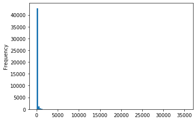

```python
#Might do the same to product_id and others
prid_s = df_data["product_id"].value_counts()
#Of course not, the product_id is long you'd waste space printing it
print('no. of products: ',len(prid_s))
#Use describe instead
print(prid_s.describe())
#So what we count here is how active ea product is, it doesnt matter what the activity though might be only viewing
#carting purchasing and even removing. But we get the big picture here that how active each product was on Nov 2019
#So we gonna step up to see which is most popular
prid_s = prid_s.sort_values(ascending=False)
print('Top 10 Active Products')
print(prid_s.head(10))
#Sadly we dont know what the real product which lies on top of the list
#Lets step up to see the product access count distribution (with histogram of course)
prid_s.plot.hist(bins=100)
#That doesnt look good right,try this
#prid_s.plot.hist(bins=[0,10,20,50,100,200,500,1000,2000,5000,10000,20000],logx=True,logy=True)
```

```
no. of category 482
Top 10 Category
1487580007675986893    2388
1487580013841613016    1700
1487580005595612013    1045
1487580008246412266    1029
1487580011585077370     868
1487580005671109489     847
1487580006317032337     837
1487580005461394279     704
1487580005092295511     664
1658462125284131265     631
Name: category_id, dtype: int64
Last 10 Category
1487580010150625337    1
1487580011140481125    1
1487580005159404378    1
1543705961326182546    1
1759024699007828783    1
1628099626433249931    1
1487580008951054345    1
1911999948073730325    1
1487580012046450826    1
1487580010075127862    1
Name: category_id, dtype: int64
```

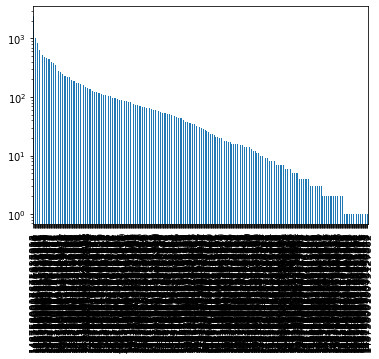

```python
category_dict=df_data[['category_id','product_id']].drop_duplicates()
print('no. of category',len(df_data['category_id'].drop_duplicates()))
cat_counts=category_dict['category_id'].value_counts().sort_values(ascending=False)
print('Top 10 Category')
print(cat_counts.head(10))
print('Last 10 Category')
print(cat_counts.tail(10))
cat_counts.plot.bar(logy=True)
```

```
<class 'pandas.core.series.Series'>
1487580007675986893    216293
1487580005595612013    128438
1487580005092295511    123455
1602943681873052386    117336
1487580006317032337    104204
1487580005671109489     98988
1487580005754995573     88506
1487580013841613016     86137
1487580005268456287     74537
1487580008246412266     69095
Name: category_id, dtype: int64
1487580007675986893    2388
1487580013841613016    1700
1487580005595612013    1045
1487580008246412266    1029
1487580011585077370     868
1487580005671109489     847
1487580006317032337     837
1487580005461394279     704
1487580005092295511     664
1658462125284131265     631
Name: category_id, dtype: int64
482
482
Int64Index([1487580007675986893, 1487580005595612013, 1487580005092295511,
            1602943681873052386, 1487580006317032337, 1487580005671109489,
            1487580005754995573, 1487580013841613016, 1487580005268456287,
            1487580008246412266],
           dtype='int64')
Int64Index([1487580007675986893, 1487580013841613016, 1487580005595612013,
            1487580008246412266, 1487580011585077370, 1487580005671109489,
            1487580006317032337, 1487580005461394279, 1487580005092295511,
            1658462125284131265],
           dtype='int64')
```

```
                     activeness
1487580007675986893      216293
1487580005595612013      128438
1487580005092295511      123455
1602943681873052386      117336
1487580006317032337      104204
1487580005671109489       98988
1487580005754995573       88506
1487580013841613016       86137
1487580005268456287       74537
1487580008246412266       69095
                     n_product
1487580007675986893       2388
1487580013841613016       1700
1487580005595612013       1045
1487580008246412266       1029
1487580011585077370        868
1487580005671109489        847
1487580006317032337        837
1487580005461394279        704
1487580005092295511        664
1658462125284131265        631
```

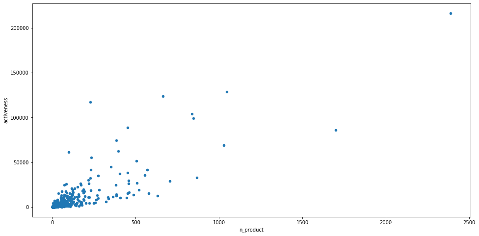

```python
print(type(cat_counts)) #Check the type of cat_count oh no its a series
cat_act_c=df_data['category_id'].value_counts()
print(cat_act_c.head(10))
print(cat_counts.head(10))
print(len(cat_act_c.index))
print(len(cat_counts.index))
print(cat_act_c.index[:10])
print(cat_counts.index[:10])
#we can see the number of cat is same however it isnt aligned
#if we join
df_act_cat=pd.DataFrame(cat_act_c)
df_act_cat.rename(columns={'category_id':'activeness'}, inplace=True)
df_cnt_cat=pd.DataFrame(cat_counts)
df_cnt_cat.rename(columns={'category_id':'n_product'}, inplace=True)
print(df_act_cat.head(10))
print(df_cnt_cat.head(10))
joined = df_act_cat.join(df_cnt_cat)
joined.head(10)
# Oh it actually joined well because the index is already the category number
joined.plot.scatter(x='n_product',y='activeness',figsize=(16,8))
```

```python
print(df_data['category_code'].value_counts())
print('allRows =',len(df_data.index))
print('nulls =',len(df_data.index)-sum(df_data['category_code'].value_counts()))
```

```
appliances.environment.vacuum             25818
stationery.cartrige                        9500
apparel.glove                              8295
accessories.bag                            4938
furniture.living_room.cabinet              4478
furniture.bathroom.bath                    3529
appliances.personal.hair_cutter            1102
accessories.cosmetic_bag                    693
appliances.environment.air_conditioner       92
furniture.living_room.chair                  20
Name: category_code, dtype: int64
allRows = 3533286
nulls = 3474821
```

```python
print(df_data['brand'].value_counts())
print('allRows =',len(df_data.index))
print('nulls =',len(df_data.index)-sum(df_data['brand'].value_counts()))
print(df_data['brand'].value_counts().head(20))
print('brand accessed ', sum(df_data['brand'].value_counts())/len(df_data.index)*100)
```

```
runail       256217
grattol      155920
irisk        152518
masura       125185
bpw.style     81394
              ...
ikoo              3
shifei            1
dessata           1
macadamia         1
ibd               1
Name: brand, Length: 252, dtype: int64
allRows = 3533286
nulls = 1510289
runail        256217
grattol       155920
irisk         152518
masura        125185
bpw.style      81394
estel          76649
kapous         69935
ingarden       64273
jessnail       50383
pole           47654
uno            41507
bluesky        40008
concept        36831
italwax        36172
freedecor      35952
cnd            31530
milv           29205
haruyama       28989
domix          26081
cosmoprofi     21473
Name: brand, dtype: int64
brand accessed  57.25539908176128
```

```
-79.37       2
-47.62       4
-23.81       2
-15.87       8
-7.94        2
 0.00     7589
 0.05      554
 0.06      209
 0.08      768
 0.10       45
Name: price, dtype: int64
```

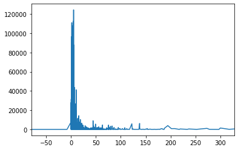

```python
c_p_act = df_data['price'].value_counts()
c_p_act.sort_index(inplace=True)
print(c_p_act.head(10))
c_p_act.plot.line()
```

```python
#So we're down to five lets see the transaction of each product
print(df_data.loc[df_data['product_id']==5716855][['event_time','event_type','product_id','price','user_id']])
#Straight purchase huh
print(df_data.loc[df_data['product_id']==5716859][['event_time','event_type','product_id','price','user_id']])
print(df_data.loc[df_data['product_id']==5716857][['event_time','event_type','product_id','price','user_id']])
print(df_data.loc[df_data['product_id']==5716861][['event_time','event_type','product_id','price','user_id']])
print(df_data.loc[df_data['product_id']==5670257][['event_time','event_type','product_id','price','user_id']])
```

```
                 event_time event_type  product_id  price    user_id
2143702 2019-12-17 10:37:03   purchase     5716855  -7.94  584498077
3328682 2019-12-28 15:42:00   purchase     5716855  -7.94  539714006
                 event_time event_type  product_id  price    user_id
1633142 2019-12-13 08:44:49   purchase     5716859 -47.62  414087247
2548146 2019-12-20 17:56:16   purchase     5716859 -47.62  589538798
2754627 2019-12-22 19:31:01   purchase     5716859 -47.62  590958276
3295546 2019-12-28 07:32:52   purchase     5716859 -47.62  545859098
                 event_time event_type  product_id  price    user_id
1667368 2019-12-13 13:48:10   purchase     5716857 -23.81  584773479
3098833 2019-12-25 20:37:02   purchase     5716857 -23.81  592544594
                 event_time event_type  product_id  price    user_id
3053899 2019-12-25 13:01:21   purchase     5716861 -79.37  489184067
3403149 2019-12-29 14:30:17   purchase     5716861 -79.37  489118334
                 event_time event_type  product_id  price    user_id
693061  2019-12-06 08:44:06   purchase     5670257 -15.87  410016187
942049  2019-12-08 12:38:35   purchase     5670257 -15.87  579811230
2143701 2019-12-17 10:37:03   purchase     5670257 -15.87  584498077
2164651 2019-12-17 13:31:01   purchase     5670257 -15.87  513455730
3220372 2019-12-27 08:34:06   purchase     5670257 -15.87  588438828
3220373 2019-12-27 08:34:06   purchase     5670257 -15.87  588438828
3295882 2019-12-28 07:39:08   purchase     5670257 -15.87  410016187
3418052 2019-12-29 17:49:32   purchase     5670257 -15.87  594077054
```

```python
df_data['user_id'].value_counts()
```

```
527021202    8689
572631412    3883
467810091    3147
548810441    2426
584289031    2356
             ...
586739138       1
590937536       1
594889500       1
578079532       1
529467934       1
Name: user_id, Length: 370154, dtype: int64
```

```python
df_data.loc[(df_data['user_id']==527021202)&(df_data['event_type']=='view')].head(60)
```

|  | event_time | event_type | product_id | category_id | category_code | brand | price | user_id | user_session |
| --- | --- | --- | --- | --- | --- | --- | --- | --- | --- |
| 34121 | 2019-12-01 10:27:46 | view | 5908242 | 1487580007675986893 | NaN | NaN | 1.43 | 527021202 | e4d8c98e-08e5-4907-9c44-74a43acc1d9e |
| 34127 | 2019-12-01 10:27:48 | view | 5908241 | 1487580007675986893 | NaN | NaN | 1.43 | 527021202 | 2a3a6e17-76bd-406c-879c-e41b18c175a6 |
| 34133 | 2019-12-01 10:27:49 | view | 5908238 | 1487580007675986893 | NaN | NaN | 1.43 | 527021202 | 0e7d37ae-b767-4622-a83b-9a276cded5f4 |
| 34217 | 2019-12-01 10:28:32 | view | 5908239 | 1487580007675986893 | NaN | NaN | 1.43 | 527021202 | 5d533d5a-6b88-469f-a588-a87cd08952a6 |
| 34222 | 2019-12-01 10:28:33 | view | 5908237 | 1487580007675986893 | NaN | NaN | 1.43 | 527021202 | baf1eb04-e074-480f-aed7-9151fbeec0e5 |
| 34223 | 2019-12-01 10:28:35 | view | 5908234 | 1487580007675986893 | NaN | NaN | 1.43 | 527021202 | 1fd930ce-682a-4253-9982-6b0efa0f6508 |
| 34224 | 2019-12-01 10:28:35 | view | 5908235 | 1487580007675986893 | NaN | NaN | 1.43 | 527021202 | 92b38e2a-b664-47c6-bf08-ac6f36bf05a6 |
| 34225 | 2019-12-01 10:28:37 | view | 5908236 | 1487580007675986893 | NaN | NaN | 1.43 | 527021202 | 4df92259-e3cc-418e-9283-624a03cae115 |
| 34474 | 2019-12-01 10:30:42 | view | 5908229 | 1487580007675986893 | NaN | NaN | 1.43 | 527021202 | 7048746c-2b1a-40ac-82c5-3a7ce6e9ae62 |
| 34476 | 2019-12-01 10:30:42 | view | 5908231 | 1487580007675986893 | NaN | NaN | 1.43 | 527021202 | dd1405d7-2778-4593-963c-c8fec141b559 |
| 34482 | 2019-12-01 10:30:43 | view | 5908227 | 1487580007675986893 | NaN | NaN | 1.43 | 527021202 | c14ad9bd-72c8-49f2-88c0-45f3f1c1a246 |
| 34489 | 2019-12-01 10:30:45 | view | 5908228 | 1487580007675986893 | NaN | NaN | 1.43 | 527021202 | ecc2dae5-ba09-4e6c-a3ee-ff20a44d86e6 |
| 34495 | 2019-12-01 10:30:46 | view | 5908219 | 1487580007675986893 | NaN | NaN | 1.43 | 527021202 | 0291fe70-5802-49c6-9baa-f5a83510c9fb |
| 34499 | 2019-12-01 10:30:48 | view | 5908222 | 1487580007675986893 | NaN | NaN | 1.43 | 527021202 | ffca99d3-498b-4aea-8dc6-78466bedfaac |
| 34503 | 2019-12-01 10:30:49 | view | 5908221 | 1487580007675986893 | NaN | NaN | 1.43 | 527021202 | f8629939-714a-45f8-bcee-b47fd9af0331 |
| 34507 | 2019-12-01 10:30:51 | view | 5908220 | 1487580007675986893 | NaN | NaN | 1.43 | 527021202 | 8d13dc79-b5b6-4e87-b31e-cb67cf4df5f1 |
| 34508 | 2019-12-01 10:30:51 | view | 5908225 | 1487580007675986893 | NaN | NaN | 1.43 | 527021202 | 0d18dfae-8088-46b7-9c87-4fd6e146f302 |
| 34514 | 2019-12-01 10:30:53 | view | 5908217 | 1487580007675986893 | NaN | NaN | 1.43 | 527021202 | e5bfa912-b20f-4336-a7e2-923d5a043d54 |
| 34518 | 2019-12-01 10:30:54 | view | 5908214 | 1487580007675986893 | NaN | NaN | 1.43 | 527021202 | 98000ec6-9e86-4554-81a1-5b20475ab2b7 |
| 34544 | 2019-12-01 10:30:55 | view | 5908215 | 1487580007675986893 | NaN | NaN | 1.43 | 527021202 | eaec853d-c2bd-4bee-90f7-7f9cefa95778 |
| 34549 | 2019-12-01 10:30:56 | view | 5908205 | 1487580007675986893 | NaN | NaN | 1.43 | 527021202 | fad118a2-bb96-4820-b5af-8eea4404ae27 |
| 34555 | 2019-12-01 10:30:58 | view | 5908210 | 1487580007675986893 | NaN | NaN | 1.43 | 527021202 | d017b7b0-45e3-4691-be3c-9ed686a0b27e |
| 34558 | 2019-12-01 10:30:59 | view | 5908208 | 1487580007675986893 | NaN | NaN | 1.43 | 527021202 | fcda785d-a29b-46dd-89af-330b232c88f3 |
| 34560 | 2019-12-01 10:31:00 | view | 5908211 | 1487580007675986893 | NaN | NaN | 1.43 | 527021202 | 6082a4dc-ca06-451b-b3ff-9758b244c8b2 |
| 34563 | 2019-12-01 10:31:02 | view | 5908206 | 1487580007675986893 | NaN | NaN | 1.43 | 527021202 | c118e090-de6c-403c-8781-c7b3b73bb38b |
| 34565 | 2019-12-01 10:31:03 | view | 5908203 | 1487580007675986893 | NaN | NaN | 1.43 | 527021202 | 62420d5e-aaca-4c39-bbef-c6c2616468b5 |
| 34566 | 2019-12-01 10:31:04 | view | 5908204 | 1487580007675986893 | NaN | NaN | 1.43 | 527021202 | a57a6c5f-75e2-43ec-bf37-2699fbff2090 |
| 34568 | 2019-12-01 10:31:05 | view | 5908200 | 1487580007675986893 | NaN | NaN | 1.43 | 527021202 | 1edf448a-749f-491a-8abf-842deac2ae23 |
| 34575 | 2019-12-01 10:31:07 | view | 5908197 | 1487580007675986893 | NaN | NaN | 1.43 | 527021202 | 17a94528-9ac9-4335-9cdd-0a16dd92fe27 |
| 34576 | 2019-12-01 10:31:07 | view | 5908198 | 1487580007675986893 | NaN | NaN | 1.43 | 527021202 | b84da3aa-73f0-4620-a286-5ad21defdd4c |
| 34578 | 2019-12-01 10:31:08 | view | 5908202 | 1487580007675986893 | NaN | NaN | 1.43 | 527021202 | 47a03573-ca90-48e1-b57b-82735cf25c00 |
| 34579 | 2019-12-01 10:31:10 | view | 5908195 | 1487580007675986893 | NaN | NaN | 1.43 | 527021202 | c8b0256c-7868-4f5d-9d72-7bb9b1c93e0c |
| 34580 | 2019-12-01 10:31:10 | view | 5908201 | 1487580007675986893 | NaN | NaN | 1.43 | 527021202 | 5d4fb233-f159-473e-812e-0fb028d691a1 |
| 34585 | 2019-12-01 10:31:13 | view | 5908193 | 1487580007675986893 | NaN | NaN | 1.43 | 527021202 | 89aa7a2f-88d7-465e-b61e-e515c838df7d |
| 34586 | 2019-12-01 10:31:13 | view | 5908196 | 1487580007675986893 | NaN | NaN | 1.43 | 527021202 | dca53780-8051-4840-95cd-12c7158532eb |
| 34591 | 2019-12-01 10:31:15 | view | 5908194 | 1487580007675986893 | NaN | NaN | 1.43 | 527021202 | 6420a93b-152d-46e6-ab4f-c0bfdf298265 |
| 34761 | 2019-12-01 10:32:40 | view | 5908225 | 1487580007675986893 | NaN | NaN | 1.43 | 527021202 | 0d18dfae-8088-46b7-9c87-4fd6e146f302 |
| 34764 | 2019-12-01 10:32:41 | view | 5908221 | 1487580007675986893 | NaN | NaN | 1.43 | 527021202 | f8629939-714a-45f8-bcee-b47fd9af0331 |
| 34766 | 2019-12-01 10:32:42 | view | 5908222 | 1487580007675986893 | NaN | NaN | 1.43 | 527021202 | ffca99d3-498b-4aea-8dc6-78466bedfaac |
| 34770 | 2019-12-01 10:32:43 | view | 5908219 | 1487580007675986893 | NaN | NaN | 1.43 | 527021202 | 0291fe70-5802-49c6-9baa-f5a83510c9fb |
| 34771 | 2019-12-01 10:32:43 | view | 5908228 | 1487580007675986893 | NaN | NaN | 1.43 | 527021202 | ecc2dae5-ba09-4e6c-a3ee-ff20a44d86e6 |
| 34772 | 2019-12-01 10:32:44 | view | 5908227 | 1487580007675986893 | NaN | NaN | 1.43 | 527021202 | c14ad9bd-72c8-49f2-88c0-45f3f1c1a246 |
| 34774 | 2019-12-01 10:32:45 | view | 5908229 | 1487580007675986893 | NaN | NaN | 1.43 | 527021202 | 7048746c-2b1a-40ac-82c5-3a7ce6e9ae62 |
| 34777 | 2019-12-01 10:32:46 | view | 5908231 | 1487580007675986893 | NaN | NaN | 1.43 | 527021202 | dd1405d7-2778-4593-963c-c8fec141b559 |
| 34778 | 2019-12-01 10:32:46 | view | 5908236 | 1487580007675986893 | NaN | NaN | 1.43 | 527021202 | 4df92259-e3cc-418e-9283-624a03cae115 |
| 34780 | 2019-12-01 10:32:47 | view | 5908235 | 1487580007675986893 | NaN | NaN | 1.43 | 527021202 | 92b38e2a-b664-47c6-bf08-ac6f36bf05a6 |
| 34782 | 2019-12-01 10:32:48 | view | 5908234 | 1487580007675986893 | NaN | NaN | 1.43 | 527021202 | 1fd930ce-682a-4253-9982-6b0efa0f6508 |
| 34783 | 2019-12-01 10:32:48 | view | 5908237 | 1487580007675986893 | NaN | NaN | 1.43 | 527021202 | baf1eb04-e074-480f-aed7-9151fbeec0e5 |
| 34786 | 2019-12-01 10:32:49 | view | 5908239 | 1487580007675986893 | NaN | NaN | 1.43 | 527021202 | 5d533d5a-6b88-469f-a588-a87cd08952a6 |
| 34853 | 2019-12-01 10:33:27 | view | 5908189 | 1487580007675986893 | NaN | NaN | 1.43 | 527021202 | 96b14aad-1d2b-4a47-a67d-193cdc8ea83c |
| 34855 | 2019-12-01 10:33:28 | view | 5908188 | 1487580007675986893 | NaN | NaN | 1.43 | 527021202 | 43eda1b0-8648-4cf2-8fb5-79f5657956c1 |
| 34857 | 2019-12-01 10:33:29 | view | 5908185 | 1487580007675986893 | NaN | NaN | 1.43 | 527021202 | 6e3e9e96-e60c-4956-abbc-e9e3e250bceb |
| 34859 | 2019-12-01 10:33:30 | view | 5908186 | 1487580007675986893 | NaN | NaN | 1.43 | 527021202 | 88ce3685-6d9e-4485-9ba1-68162dac5ba8 |
| 34862 | 2019-12-01 10:33:32 | view | 5907876 | 1487580007675986893 | NaN | NaN | 1.43 | 527021202 | 383afcc4-2ef9-4eb6-bbfe-255127eba475 |
| 34864 | 2019-12-01 10:33:33 | view | 5907877 | 1487580007675986893 | NaN | NaN | 1.43 | 527021202 | 64029590-57e2-41fb-90cd-4e852b286bca |
| 34867 | 2019-12-01 10:33:34 | view | 5907878 | 1487580007675986893 | NaN | NaN | 1.43 | 527021202 | bb3ed20b-e9cd-40a1-bb2f-9a1ab3266c98 |
| 34869 | 2019-12-01 10:33:35 | view | 5907880 | 1487580007675986893 | NaN | NaN | 1.43 | 527021202 | 6801adad-7bb4-4fa9-8e0c-7ba66104574a |
| 34871 | 2019-12-01 10:33:37 | view | 5907875 | 1487580007675986893 | NaN | NaN | 1.43 | 527021202 | d0294cc5-b035-4158-a91f-a266b99e84b7 |
| 34874 | 2019-12-01 10:33:38 | view | 5907874 | 1487580007675986893 | NaN | NaN | 1.43 | 527021202 | 3d951c25-07b8-4f7e-b16f-2fb4d7f1beb4 |
| 34876 | 2019-12-01 10:33:39 | view | 5907873 | 1487580007675986893 | NaN | NaN | 1.43 | 527021202 | 041b3378-9a89-4adf-b30d-1294e5a8c2a6 |

```python
#lets see when they did purchase
df_data.loc[(df_data['user_id']==572631412)&(df_data['event_type']=='purchase')]
#big purchase list lets see whats going on 13 Nov
data_snippet = df_data.loc[(df_data['user_id']==572631412)&(df_data['event_time']>pd.to_datetime('2019-12-12'))&(df_data['event_time']<pd.to_datetime('2019-12-14'))]
#that what we typically want to see a session(multiple sessions actually) started with viewing and ended with purchase
#im curious of how it went for each product
data_snippet.sort_values(by=['product_id','event_time']).head(31)
```

|  | event_time | event_type | product_id | category_id | category_code | brand | price | user_id | user_session |
| --- | --- | --- | --- | --- | --- | --- | --- | --- | --- |
| 1639956 | 2019-12-13 09:42:35 | remove_from_cart | 4554 | 1487580010796548183 | NaN | runail | 0.38 | 572631412 | 9785cfc3-9783-4f7e-91b3-9cbbe5257fd6 |
| 1639960 | 2019-12-13 09:42:36 | remove_from_cart | 4554 | 1487580010796548183 | NaN | runail | 0.38 | 572631412 | 9785cfc3-9783-4f7e-91b3-9cbbe5257fd6 |
| 1639961 | 2019-12-13 09:42:36 | remove_from_cart | 4554 | 1487580010796548183 | NaN | runail | 0.38 | 572631412 | 9785cfc3-9783-4f7e-91b3-9cbbe5257fd6 |
| 1639962 | 2019-12-13 09:42:36 | remove_from_cart | 4554 | 1487580010796548183 | NaN | runail | 0.38 | 572631412 | 9785cfc3-9783-4f7e-91b3-9cbbe5257fd6 |
| 1640497 | 2019-12-13 09:44:02 | remove_from_cart | 4591 | 1487580007483048900 | NaN | runail | 5.95 | 572631412 | 9785cfc3-9783-4f7e-91b3-9cbbe5257fd6 |
| 1640499 | 2019-12-13 09:44:02 | remove_from_cart | 4591 | 1487580007483048900 | NaN | runail | 5.95 | 572631412 | 9785cfc3-9783-4f7e-91b3-9cbbe5257fd6 |
| 1716126 | 2019-12-13 21:10:23 | cart | 4600 | 1487580010796548183 | NaN | runail | 0.38 | 572631412 | d53d1c2e-9195-6051-cf7b-7332dfeae818 |
| 1639946 | 2019-12-13 09:42:34 | remove_from_cart | 4607 | 1487580010796548183 | NaN | runail | 0.38 | 572631412 | 9785cfc3-9783-4f7e-91b3-9cbbe5257fd6 |
| 1639958 | 2019-12-13 09:42:35 | remove_from_cart | 4607 | 1487580010796548183 | NaN | runail | 0.38 | 572631412 | 9785cfc3-9783-4f7e-91b3-9cbbe5257fd6 |
| 1639959 | 2019-12-13 09:42:35 | remove_from_cart | 4607 | 1487580010796548183 | NaN | runail | 0.38 | 572631412 | 9785cfc3-9783-4f7e-91b3-9cbbe5257fd6 |
| 1716145 | 2019-12-13 21:10:40 | cart | 4607 | 1487580010796548183 | NaN | runail | 0.38 | 572631412 | d53d1c2e-9195-6051-cf7b-7332dfeae818 |
| 1640044 | 2019-12-13 09:42:48 | remove_from_cart | 4620 | 1487580010821714008 | NaN | runail | 0.38 | 572631412 | 9785cfc3-9783-4f7e-91b3-9cbbe5257fd6 |
| 1640046 | 2019-12-13 09:42:48 | remove_from_cart | 4620 | 1487580010821714008 | NaN | runail | 0.38 | 572631412 | 9785cfc3-9783-4f7e-91b3-9cbbe5257fd6 |
| 1639999 | 2019-12-13 09:42:41 | remove_from_cart | 4632 | 1487580010821714008 | NaN | runail | 0.38 | 572631412 | 9785cfc3-9783-4f7e-91b3-9cbbe5257fd6 |
| 1716253 | 2019-12-13 21:11:57 | cart | 4632 | 1487580010821714008 | NaN | runail | 0.38 | 572631412 | d53d1c2e-9195-6051-cf7b-7332dfeae818 |
| 1640340 | 2019-12-13 09:43:37 | remove_from_cart | 4637 | 1487580011157258342 | NaN | runail | 0.37 | 572631412 | 9785cfc3-9783-4f7e-91b3-9cbbe5257fd6 |
| 1640350 | 2019-12-13 09:43:39 | remove_from_cart | 4637 | 1487580011157258342 | NaN | runail | 0.37 | 572631412 | 9785cfc3-9783-4f7e-91b3-9cbbe5257fd6 |
| 1716219 | 2019-12-13 21:11:31 | cart | 4637 | 1487580011157258342 | NaN | runail | 0.37 | 572631412 | d53d1c2e-9195-6051-cf7b-7332dfeae818 |
| 1640352 | 2019-12-13 09:43:39 | remove_from_cart | 4640 | 1487580011157258342 | NaN | runail | 0.37 | 572631412 | 9785cfc3-9783-4f7e-91b3-9cbbe5257fd6 |
| 1640347 | 2019-12-13 09:43:38 | remove_from_cart | 4653 | 1487580011157258342 | NaN | runail | 0.37 | 572631412 | 9785cfc3-9783-4f7e-91b3-9cbbe5257fd6 |
| 1640354 | 2019-12-13 09:43:39 | remove_from_cart | 4653 | 1487580011157258342 | NaN | runail | 0.37 | 572631412 | 9785cfc3-9783-4f7e-91b3-9cbbe5257fd6 |
| 1716285 | 2019-12-13 21:12:28 | cart | 4654 | 1487580011157258342 | NaN | runail | 0.37 | 572631412 | d53d1c2e-9195-6051-cf7b-7332dfeae818 |
| 1716266 | 2019-12-13 21:12:06 | cart | 4689 | 1487580010796548183 | NaN | runail | 0.38 | 572631412 | d53d1c2e-9195-6051-cf7b-7332dfeae818 |
| 1716269 | 2019-12-13 21:12:09 | cart | 4765 | 1487580010796548183 | NaN | runail | 0.38 | 572631412 | d53d1c2e-9195-6051-cf7b-7332dfeae818 |
| 1639937 | 2019-12-13 09:42:33 | remove_from_cart | 4768 | 1487580010796548183 | NaN | runail | 0.38 | 572631412 | 9785cfc3-9783-4f7e-91b3-9cbbe5257fd6 |
| 1639948 | 2019-12-13 09:42:34 | remove_from_cart | 4768 | 1487580010796548183 | NaN | runail | 0.38 | 572631412 | 9785cfc3-9783-4f7e-91b3-9cbbe5257fd6 |
| 1639949 | 2019-12-13 09:42:34 | remove_from_cart | 4768 | 1487580010796548183 | NaN | runail | 0.38 | 572631412 | 9785cfc3-9783-4f7e-91b3-9cbbe5257fd6 |
| 1639950 | 2019-12-13 09:42:34 | remove_from_cart | 4768 | 1487580010796548183 | NaN | runail | 0.38 | 572631412 | 9785cfc3-9783-4f7e-91b3-9cbbe5257fd6 |
| 1716128 | 2019-12-13 21:10:26 | cart | 4768 | 1487580010796548183 | NaN | runail | 0.38 | 572631412 | d53d1c2e-9195-6051-cf7b-7332dfeae818 |
| 1639975 | 2019-12-13 09:42:38 | remove_from_cart | 4793 | 1487580010796548183 | NaN | runail | 0.38 | 572631412 | 9785cfc3-9783-4f7e-91b3-9cbbe5257fd6 |
| 1639976 | 2019-12-13 09:42:38 | remove_from_cart | 4793 | 1487580010796548183 | NaN | runail | 0.38 | 572631412 | 9785cfc3-9783-4f7e-91b3-9cbbe5257fd6 |

```python
cross_usev=pd.crosstab(df_data['user_id'],df_data['event_type'])
print(cross_usev.sort_values(by='purchase',ascending=False).head(20))
```

```
event_type  cart  purchase  remove_from_cart  view
user_id
575709540    606       399                60    86
517825140    535       376               108    67
404207391    318       204                18    19
572631412   1336       199              2309    39
471099630    252       190                38     9
586168240    299       187               135    22
565156776    263       182               127    65
579751441    189       171                87     4
571906276    130       162                39    20
587728207    335       161                85   183
442763940    173       155                54    55
493285103    243       154                75    75
268843016    290       145               265   389
480463194    230       137                22     9
540678302    195       135                55    19
565036131    548       126               463   160
572081598    191       122                41   403
582527394    160       121                61    11
586915968    174       120                90   158
254974330    222       120               118    52
```

```python
#lets see when they did purchase
df_data.loc[(df_data['user_id']==575709540)&(df_data['event_type']=='purchase')]
#big purchase list lets see whats going on 13 Nov
data_snippet = df_data.loc[(df_data['user_id']==575709540)&(df_data['event_time']>pd.to_datetime('2019-12-1'))&(df_data['event_time']<pd.to_datetime('2019-12-14'))]
#that what we typically want to see a session(multiple sessions actually) started with viewing and ended with purchase
#im curious of how it went for each product
data_snippet.sort_values(by=['product_id','event_time']).head(31)
```

|  | event_time | event_type | product_id | category_id | category_code | brand | price | user_id | user_session |
| --- | --- | --- | --- | --- | --- | --- | --- | --- | --- |
| 124666 | 2019-12-01 22:25:44 | cart | 4554 | 1487580010796548183 | NaN | runail | 0.38 | 575709540 | 4b8377a1-cb36-43f9-8551-f27f2a1214a9 |
| 198332 | 2019-12-02 14:12:08 | purchase | 4554 | 1487580010796548183 | NaN | runail | 0.38 | 575709540 | 416c2ca2-f14c-476c-a9d3-31eeed117e66 |
| 124692 | 2019-12-01 22:26:04 | cart | 4571 | 1487580010796548183 | NaN | runail | 0.38 | 575709540 | 4b8377a1-cb36-43f9-8551-f27f2a1214a9 |
| 198333 | 2019-12-02 14:12:08 | purchase | 4571 | 1487580010796548183 | NaN | runail | 0.38 | 575709540 | 416c2ca2-f14c-476c-a9d3-31eeed117e66 |
| 124687 | 2019-12-01 22:26:00 | cart | 4587 | 1487580010796548183 | NaN | runail | 0.38 | 575709540 | 4b8377a1-cb36-43f9-8551-f27f2a1214a9 |
| 198334 | 2019-12-02 14:12:08 | purchase | 4587 | 1487580010796548183 | NaN | runail | 0.38 | 575709540 | 416c2ca2-f14c-476c-a9d3-31eeed117e66 |
| 582687 | 2019-12-05 10:53:14 | cart | 4591 | 1487580007483048900 | NaN | runail | 5.95 | 575709540 | 8b6caec5-32ea-4fa9-8514-d7e22c983198 |
| 641394 | 2019-12-05 19:08:38 | purchase | 4591 | 1487580007483048900 | NaN | runail | 5.95 | 575709540 | 44449ba6-bb85-37c8-a592-c4b835390cf6 |
| 124695 | 2019-12-01 22:26:07 | cart | 4602 | 1487580010796548183 | NaN | runail | 0.38 | 575709540 | 4b8377a1-cb36-43f9-8551-f27f2a1214a9 |
| 198335 | 2019-12-02 14:12:08 | purchase | 4602 | 1487580010796548183 | NaN | runail | 0.38 | 575709540 | 416c2ca2-f14c-476c-a9d3-31eeed117e66 |
| 124696 | 2019-12-01 22:26:10 | cart | 4604 | 1487580010796548183 | NaN | runail | 0.38 | 575709540 | 4b8377a1-cb36-43f9-8551-f27f2a1214a9 |
| 198336 | 2019-12-02 14:12:08 | purchase | 4604 | 1487580010796548183 | NaN | runail | 0.38 | 575709540 | 416c2ca2-f14c-476c-a9d3-31eeed117e66 |
| 124700 | 2019-12-01 22:26:16 | cart | 4607 | 1487580010796548183 | NaN | runail | 0.38 | 575709540 | 4b8377a1-cb36-43f9-8551-f27f2a1214a9 |
| 198337 | 2019-12-02 14:12:08 | purchase | 4607 | 1487580010796548183 | NaN | runail | 0.38 | 575709540 | 416c2ca2-f14c-476c-a9d3-31eeed117e66 |
| 124703 | 2019-12-01 22:26:17 | cart | 4680 | 1487580010796548183 | NaN | runail | 0.38 | 575709540 | 4b8377a1-cb36-43f9-8551-f27f2a1214a9 |
| 198338 | 2019-12-02 14:12:08 | purchase | 4680 | 1487580010796548183 | NaN | runail | 0.38 | 575709540 | 416c2ca2-f14c-476c-a9d3-31eeed117e66 |
| 124677 | 2019-12-01 22:25:54 | cart | 4683 | 1487580010796548183 | NaN | runail | 0.38 | 575709540 | 4b8377a1-cb36-43f9-8551-f27f2a1214a9 |
| 198339 | 2019-12-02 14:12:08 | purchase | 4683 | 1487580010796548183 | NaN | runail | 0.38 | 575709540 | 416c2ca2-f14c-476c-a9d3-31eeed117e66 |
| 124670 | 2019-12-01 22:25:47 | cart | 4758 | 1487580010796548183 | NaN | runail | 0.38 | 575709540 | 4b8377a1-cb36-43f9-8551-f27f2a1214a9 |
| 198340 | 2019-12-02 14:12:08 | purchase | 4758 | 1487580010796548183 | NaN | runail | 0.38 | 575709540 | 416c2ca2-f14c-476c-a9d3-31eeed117e66 |
| 124682 | 2019-12-01 22:25:57 | cart | 4764 | 1487580010796548183 | NaN | runail | 0.38 | 575709540 | 4b8377a1-cb36-43f9-8551-f27f2a1214a9 |
| 198341 | 2019-12-02 14:12:08 | purchase | 4764 | 1487580010796548183 | NaN | runail | 0.38 | 575709540 | 416c2ca2-f14c-476c-a9d3-31eeed117e66 |
| 124674 | 2019-12-01 22:25:51 | cart | 4765 | 1487580010796548183 | NaN | runail | 0.38 | 575709540 | 4b8377a1-cb36-43f9-8551-f27f2a1214a9 |
| 198342 | 2019-12-02 14:12:08 | purchase | 4765 | 1487580010796548183 | NaN | runail | 0.38 | 575709540 | 416c2ca2-f14c-476c-a9d3-31eeed117e66 |
| 124706 | 2019-12-01 22:26:18 | cart | 4808 | 1487580010796548183 | NaN | runail | 0.38 | 575709540 | 4b8377a1-cb36-43f9-8551-f27f2a1214a9 |
| 198343 | 2019-12-02 14:12:08 | purchase | 4808 | 1487580010796548183 | NaN | runail | 0.38 | 575709540 | 416c2ca2-f14c-476c-a9d3-31eeed117e66 |
| 124707 | 2019-12-01 22:26:19 | cart | 4820 | 1487580010796548183 | NaN | runail | 0.38 | 575709540 | 4b8377a1-cb36-43f9-8551-f27f2a1214a9 |
| 198344 | 2019-12-02 14:12:08 | purchase | 4820 | 1487580010796548183 | NaN | runail | 0.38 | 575709540 | 416c2ca2-f14c-476c-a9d3-31eeed117e66 |
| 124699 | 2019-12-01 22:26:14 | cart | 4870 | 1487580010796548183 | NaN | runail | 0.38 | 575709540 | 4b8377a1-cb36-43f9-8551-f27f2a1214a9 |
| 198345 | 2019-12-02 14:12:08 | purchase | 4870 | 1487580010796548183 | NaN | runail | 0.38 | 575709540 | 416c2ca2-f14c-476c-a9d3-31eeed117e66 |
| 123714 | 2019-12-01 22:10:31 | cart | 4938 | 1487580008187692007 | NaN | runail | 1.43 | 575709540 | 4b8377a1-cb36-43f9-8551-f27f2a1214a9 |

```python
df_data.loc[(df_data['user_id']==575709540)&(df_data['event_type']=='purchase')].tail(60)
```

|  | event_time | event_type | product_id | category_id | category_code | brand | price | user_id | user_session |
| --- | --- | --- | --- | --- | --- | --- | --- | --- | --- |
| 641434 | 2019-12-05 19:08:38 | purchase | 5839715 | 1487580013841613016 | NaN | estel | 5.79 | 575709540 | 44449ba6-bb85-37c8-a592-c4b835390cf6 |
| 641435 | 2019-12-05 19:08:38 | purchase | 5839716 | 1487580013841613016 | NaN | estel | 5.79 | 575709540 | 44449ba6-bb85-37c8-a592-c4b835390cf6 |
| 641436 | 2019-12-05 19:08:38 | purchase | 5839720 | 1487580013841613016 | NaN | estel | 5.79 | 575709540 | 44449ba6-bb85-37c8-a592-c4b835390cf6 |
| 641437 | 2019-12-05 19:08:38 | purchase | 5839721 | 1487580013841613016 | NaN | estel | 5.79 | 575709540 | 44449ba6-bb85-37c8-a592-c4b835390cf6 |
| 641438 | 2019-12-05 19:08:38 | purchase | 5839723 | 1487580013841613016 | NaN | estel | 5.79 | 575709540 | 44449ba6-bb85-37c8-a592-c4b835390cf6 |
| 641439 | 2019-12-05 19:08:38 | purchase | 5861343 | 1487580009471148064 | NaN | NaN | 1.84 | 575709540 | 44449ba6-bb85-37c8-a592-c4b835390cf6 |
| 641440 | 2019-12-05 19:08:38 | purchase | 6732 | 1487580013027917999 | NaN | NaN | 8.41 | 575709540 | 44449ba6-bb85-37c8-a592-c4b835390cf6 |
| 641441 | 2019-12-05 19:08:38 | purchase | 6818 | 1487580013027917999 | NaN | NaN | 1.51 | 575709540 | 44449ba6-bb85-37c8-a592-c4b835390cf6 |
| 1015381 | 2019-12-08 23:17:36 | purchase | 5528 | 2196456817641391019 | NaN | ingarden | 5.24 | 575709540 | 8288f1b6-6c41-42b5-af16-2c0050ec295f |
| 1015382 | 2019-12-08 23:17:36 | purchase | 5539 | 1783999064136745198 | NaN | ingarden | 7.78 | 575709540 | 8288f1b6-6c41-42b5-af16-2c0050ec295f |
| 1015383 | 2019-12-08 23:17:36 | purchase | 5809568 | 2196456817641391019 | NaN | NaN | 3.49 | 575709540 | 8288f1b6-6c41-42b5-af16-2c0050ec295f |
| 1015384 | 2019-12-08 23:17:36 | purchase | 5809570 | 2196456817641391019 | NaN | NaN | 5.87 | 575709540 | 8288f1b6-6c41-42b5-af16-2c0050ec295f |
| 1015385 | 2019-12-08 23:17:36 | purchase | 5937 | 2196456817758831535 | NaN | runail | 5.48 | 575709540 | 8288f1b6-6c41-42b5-af16-2c0050ec295f |
| 1015386 | 2019-12-08 23:17:36 | purchase | 6941 | 1783999064103190764 | NaN | runail | 4.71 | 575709540 | 8288f1b6-6c41-42b5-af16-2c0050ec295f |
| 1015387 | 2019-12-08 23:17:36 | purchase | 6942 | 1783999064103190764 | NaN | runail | 4.71 | 575709540 | 8288f1b6-6c41-42b5-af16-2c0050ec295f |
| 1015388 | 2019-12-08 23:17:36 | purchase | 6943 | 1783999064103190764 | NaN | runail | 4.71 | 575709540 | 8288f1b6-6c41-42b5-af16-2c0050ec295f |
| 1015389 | 2019-12-08 23:17:36 | purchase | 6944 | 1783999064136745198 | NaN | runail | 4.92 | 575709540 | 8288f1b6-6c41-42b5-af16-2c0050ec295f |
| 1015390 | 2019-12-08 23:17:36 | purchase | 6945 | 1783999064103190764 | NaN | runail | 4.71 | 575709540 | 8288f1b6-6c41-42b5-af16-2c0050ec295f |
| 1015391 | 2019-12-08 23:17:36 | purchase | 6946 | 1783999064103190764 | NaN | runail | 4.71 | 575709540 | 8288f1b6-6c41-42b5-af16-2c0050ec295f |
| 1015392 | 2019-12-08 23:17:36 | purchase | 6947 | 1783999064103190764 | NaN | runail | 4.75 | 575709540 | 8288f1b6-6c41-42b5-af16-2c0050ec295f |
| 1015393 | 2019-12-08 23:17:36 | purchase | 6948 | 1783999064136745198 | NaN | runail | 4.92 | 575709540 | 8288f1b6-6c41-42b5-af16-2c0050ec295f |
| 1015394 | 2019-12-08 23:17:36 | purchase | 6963 | 1783999064136745198 | NaN | runail | 5.13 | 575709540 | 8288f1b6-6c41-42b5-af16-2c0050ec295f |
| 1015395 | 2019-12-08 23:17:36 | purchase | 6977 | 1783999064136745198 | NaN | runail | 5.13 | 575709540 | 8288f1b6-6c41-42b5-af16-2c0050ec295f |
| 1015396 | 2019-12-08 23:17:36 | purchase | 6978 | 1783999064136745198 | NaN | runail | 5.13 | 575709540 | 8288f1b6-6c41-42b5-af16-2c0050ec295f |
| 1015397 | 2019-12-08 23:17:36 | purchase | 6979 | 1783999064136745198 | NaN | runail | 5.13 | 575709540 | 8288f1b6-6c41-42b5-af16-2c0050ec295f |
| 1015398 | 2019-12-08 23:17:36 | purchase | 6991 | 1783999064136745198 | NaN | runail | 3.25 | 575709540 | 8288f1b6-6c41-42b5-af16-2c0050ec295f |
| 1015399 | 2019-12-08 23:17:36 | purchase | 6992 | 1783999064136745198 | NaN | runail | 3.25 | 575709540 | 8288f1b6-6c41-42b5-af16-2c0050ec295f |
| 1015400 | 2019-12-08 23:17:36 | purchase | 7679 | 1516331853567492962 | NaN | runail | 3.10 | 575709540 | 8288f1b6-6c41-42b5-af16-2c0050ec295f |
| 2166423 | 2019-12-17 13:46:22 | purchase | 5529097 | 1487580013027917999 | NaN | NaN | 5.29 | 575709540 | 29b2e9dc-922a-40b6-99d0-77cc925caed3 |
| 2166424 | 2019-12-17 13:46:22 | purchase | 5584850 | 1487580013615120588 | NaN | NaN | 3.63 | 575709540 | 29b2e9dc-922a-40b6-99d0-77cc925caed3 |
| 2166425 | 2019-12-17 13:46:22 | purchase | 5584856 | 1487580009445982239 | NaN | NaN | 1.17 | 575709540 | 29b2e9dc-922a-40b6-99d0-77cc925caed3 |
| 2166426 | 2019-12-17 13:46:22 | purchase | 5649305 | 1487580010335174721 | NaN | concept | 6.03 | 575709540 | 29b2e9dc-922a-40b6-99d0-77cc925caed3 |
| 2166427 | 2019-12-17 13:46:22 | purchase | 5650119 | 1487580008313521133 | NaN | concept | 6.75 | 575709540 | 29b2e9dc-922a-40b6-99d0-77cc925caed3 |
| 2166428 | 2019-12-17 13:46:22 | purchase | 5650146 | 1783999067156644376 | NaN | concept | 5.08 | 575709540 | 29b2e9dc-922a-40b6-99d0-77cc925caed3 |
| 2166429 | 2019-12-17 13:46:22 | purchase | 5650583 | 1487580010293231679 | NaN | concept | 6.90 | 575709540 | 29b2e9dc-922a-40b6-99d0-77cc925caed3 |
| 2166430 | 2019-12-17 13:46:22 | purchase | 5676783 | 1783999067156644376 | NaN | estel | 7.94 | 575709540 | 29b2e9dc-922a-40b6-99d0-77cc925caed3 |
| 2166431 | 2019-12-17 13:46:22 | purchase | 5677466 | 1487580013732561106 | NaN | estel | 11.90 | 575709540 | 29b2e9dc-922a-40b6-99d0-77cc925caed3 |
| 2166432 | 2019-12-17 13:46:22 | purchase | 5677622 | 1487580013858390233 | NaN | estel | 6.11 | 575709540 | 29b2e9dc-922a-40b6-99d0-77cc925caed3 |
| 2166433 | 2019-12-17 13:46:22 | purchase | 5677623 | 1487580013858390233 | NaN | estel | 6.11 | 575709540 | 29b2e9dc-922a-40b6-99d0-77cc925caed3 |
| 2166434 | 2019-12-17 13:46:22 | purchase | 5677936 | 1487580013824835799 | NaN | estel | 4.60 | 575709540 | 29b2e9dc-922a-40b6-99d0-77cc925caed3 |
| 2166435 | 2019-12-17 13:46:22 | purchase | 5678033 | 1487580010217734204 | NaN | estel | 4.60 | 575709540 | 29b2e9dc-922a-40b6-99d0-77cc925caed3 |
| 2166436 | 2019-12-17 13:46:22 | purchase | 5678034 | 1487580010217734204 | NaN | estel | 4.60 | 575709540 | 29b2e9dc-922a-40b6-99d0-77cc925caed3 |
| 2166437 | 2019-12-17 13:46:22 | purchase | 5697464 | 1487580013732561106 | NaN | estel | 14.29 | 575709540 | 29b2e9dc-922a-40b6-99d0-77cc925caed3 |
| 2166438 | 2019-12-17 13:46:22 | purchase | 5739030 | 1645114480121610699 | NaN | kapous | 3.97 | 575709540 | 29b2e9dc-922a-40b6-99d0-77cc925caed3 |
| 2166439 | 2019-12-17 13:46:22 | purchase | 5815454 | 1487580010242900029 | NaN | NaN | 6.70 | 575709540 | 29b2e9dc-922a-40b6-99d0-77cc925caed3 |
| 2166440 | 2019-12-17 13:46:22 | purchase | 5827468 | 1791442895991997390 | NaN | estel | 7.94 | 575709540 | 29b2e9dc-922a-40b6-99d0-77cc925caed3 |
| 2166441 | 2019-12-17 13:46:22 | purchase | 5827469 | 1791442895991997390 | NaN | estel | 10.63 | 575709540 | 29b2e9dc-922a-40b6-99d0-77cc925caed3 |
| 2166442 | 2019-12-17 13:46:22 | purchase | 5827473 | 1791442895991997390 | NaN | estel | 14.29 | 575709540 | 29b2e9dc-922a-40b6-99d0-77cc925caed3 |
| 2166443 | 2019-12-17 13:46:22 | purchase | 5843998 | 1487580010293231679 | NaN | NaN | 4.60 | 575709540 | 29b2e9dc-922a-40b6-99d0-77cc925caed3 |
| 2166444 | 2019-12-17 13:46:22 | purchase | 5844007 | 1487580010293231679 | NaN | NaN | 4.46 | 575709540 | 29b2e9dc-922a-40b6-99d0-77cc925caed3 |
| 2166445 | 2019-12-17 13:46:22 | purchase | 5857851 | 1791442895991997390 | NaN | levrana | 6.35 | 575709540 | 29b2e9dc-922a-40b6-99d0-77cc925caed3 |
| 2166446 | 2019-12-17 13:46:22 | purchase | 5868467 | 1487580009445982239 | NaN | NaN | 0.95 | 575709540 | 29b2e9dc-922a-40b6-99d0-77cc925caed3 |
| 2166447 | 2019-12-17 13:46:22 | purchase | 5868477 | 1487580009445982239 | NaN | NaN | 4.13 | 575709540 | 29b2e9dc-922a-40b6-99d0-77cc925caed3 |
| 2166448 | 2019-12-17 13:46:22 | purchase | 5868478 | 1487580009445982239 | NaN | NaN | 4.13 | 575709540 | 29b2e9dc-922a-40b6-99d0-77cc925caed3 |
| 2166449 | 2019-12-17 13:46:22 | purchase | 5878408 | 1791442895991997390 | NaN | NaN | 6.98 | 575709540 | 29b2e9dc-922a-40b6-99d0-77cc925caed3 |
| 2166450 | 2019-12-17 13:46:22 | purchase | 5878410 | 1791442895991997390 | NaN | NaN | 10.48 | 575709540 | 29b2e9dc-922a-40b6-99d0-77cc925caed3 |
| 2166451 | 2019-12-17 13:46:22 | purchase | 5886429 | 1487580010318397504 | NaN | chi | 11.54 | 575709540 | 29b2e9dc-922a-40b6-99d0-77cc925caed3 |
| 2166452 | 2019-12-17 13:46:22 | purchase | 5892542 | 2145935122136826354 | NaN | metzger | 12.54 | 575709540 | 29b2e9dc-922a-40b6-99d0-77cc925caed3 |
| 2166453 | 2019-12-17 13:46:22 | purchase | 5914104 | 1487580013824835799 | NaN | dewal | 1.16 | 575709540 | 29b2e9dc-922a-40b6-99d0-77cc925caed3 |
| 2166454 | 2019-12-17 13:46:22 | purchase | 6732 | 1487580013027917999 | NaN | NaN | 8.41 | 575709540 | 29b2e9dc-922a-40b6-99d0-77cc925caed3 |

```python
NovWithBrand = df_data.dropna(subset=['brand'])
```

```python
NovWithBrand = NovWithBrand.groupby('brand')
```

```python
Brands = pd.DataFrame(columns = ['Brand', 'Revenue', 'Count Total', '% Purchase', '% Cart Add', 'Count Products', 'Count Users' ,'AVG Price'])
Brands
i=0
for brand, data in NovWithBrand:
    i+=1
    Brands.loc[i,'Brand'] = brand
    Brands.loc[i,'Revenue'] = data[data['event_type']=='purchase']['price'].sum()
    Brands.loc[i,'Count Total'] = len(data)
    Brands.loc[i,'% Purchase'] = len(data[data['event_type']=='purchase']) / Brands.loc[i,'Count Total']
    Brands.loc[i,'% Cart Add'] = len(data[data['event_type']=='cart']) / Brands.loc[i,'Count Total']
    Brands.loc[i,'Count Products'] = data['product_id'].nunique()
    Brands.loc[i,'Count Users'] = data['user_id'].nunique()
    Brands.loc[i,'AVG Price'] = data[['product_id','price']].drop_duplicates()['price'].mean()
```

```python
# Print with % style
Brands.style.format({'% Purchase': "{:.2%}",'% Cart Add': "{:.2%}"})
```

|  | Brand | Revenue | Count Total | % Purchase | % Cart Add | Count Products | Count Users | AVG Price |
| --- | --- | --- | --- | --- | --- | --- | --- | --- |
| 1 | airnails | 4113.27 | 14430 | 9.55% | 32.75% | 195 | 3356 | 2.16835 |
| 2 | almea | 677.87 | 826 | 3.75% | 13.92% | 32 | 462 | 20.2291 |
| 3 | andrea | 5.54 | 90 | 1.11% | 6.67% | 2 | 60 | 5.54 |
| 4 | ardell | 1002.52 | 4969 | 3.18% | 15.60% | 55 | 1964 | 6.62069 |
| 5 | art-visage | 2023.1 | 10704 | 6.85% | 31.93% | 68 | 4010 | 3.36647 |
| 6 | artex | 2183.02 | 4144 | 5.84% | 23.05% | 16 | 1704 | 10.5135 |
| 7 | aura | 76.05 | 220 | 5.45% | 21.36% | 10 | 102 | 7.925 |
| 8 | australis | 0 | 39 | 0.00% | 0.00% | 16 | 34 | 19.8912 |
| 9 | avene | 115.65 | 219 | 2.74% | 21.46% | 53 | 111 | 19.6221 |
| 10 | babyliss | 386.17 | 1233 | 0.65% | 7.95% | 41 | 679 | 71.4246 |
| 11 | balbcare | 317 | 1594 | 6.27% | 37.52% | 2 | 513 | 3.17 |
| 12 | barbie | 9.37 | 10 | 10.00% | 20.00% | 2 | 4 | 6.75 |
| 13 | barex | 614.06 | 823 | 4.37% | 16.04% | 16 | 354 | 18.5278 |
| 14 | batiste | 511.65 | 789 | 6.34% | 22.18% | 26 | 359 | 9.62778 |
| 15 | beautific | 39.64 | 242 | 1.24% | 17.36% | 53 | 126 | 20.2002 |
| 16 | beautix | 9166.87 | 15010 | 5.07% | 23.23% | 324 | 3093 | 12.0435 |
| 17 | beauty-free | 426.28 | 3379 | 5.15% | 28.23% | 133 | 981 | 3.1945 |
| 18 | beautyblender | 42.54 | 199 | 1.01% | 8.54% | 16 | 124 | 24.5062 |
| 19 | beauugreen | 427.67 | 573 | 4.54% | 19.02% | 6 | 300 | 28.5167 |
| 20 | benovy | 2551.53 | 3658 | 10.44% | 33.62% | 24 | 1297 | 7.47462 |
| 21 | bergamo | 149.61 | 335 | 4.48% | 20.30% | 26 | 137 | 14.4523 |
| 22 | bespecial | 168.39 | 548 | 2.74% | 15.33% | 18 | 301 | 10.6063 |
| 23 | binacil | 26.23 | 110 | 3.64% | 17.27% | 6 | 68 | 6.37833 |
| 24 | bioaqua | 1300.68 | 5295 | 4.23% | 19.28% | 106 | 2482 | 7.0425 |
| 25 | biofollica | 317.76 | 542 | 4.06% | 12.55% | 8 | 277 | 15.7311 |
| 26 | biore | 40.3 | 155 | 1.94% | 29.68% | 13 | 82 | 13.6793 |
| 27 | biorepair | 77.17 | 313 | 1.92% | 18.85% | 17 | 156 | 14.8359 |
| 28 | blise | 0 | 8 | 0.00% | 0.00% | 1 | 8 | 60.32 |
| 29 | blixz | 29.31 | 453 | 3.75% | 27.59% | 28 | 258 | 2.03878 |
| 30 | bluesky | 8490.36 | 40008 | 5.12% | 28.48% | 793 | 8571 | 4.71099 |

[output cut: 222 more lines]

```python
# Cast to int and floats data types
Brands[['Revenue','Count Total','Count Products','Count Users']]=Brands[['Revenue','Count Total','Count Products','Count Users']].astype('int')
Brands[['% Purchase','% Cart Add','%AVG Price']]=Brands[['% Purchase','% Cart Add','AVG Price']].astype('float')
Brands.info()
```

```
<class 'pandas.core.frame.DataFrame'>
Int64Index: 252 entries, 1 to 252
Data columns (total 9 columns):
Brand             252 non-null object
Revenue           252 non-null int32
Count Total       252 non-null int32
% Purchase        252 non-null float64
% Cart Add        252 non-null float64
Count Products    252 non-null int32
Count Users       252 non-null int32
AVG Price         252 non-null object
%AVG Price        252 non-null float64
dtypes: float64(3), int32(4), object(2)
memory usage: 25.8+ KB
```

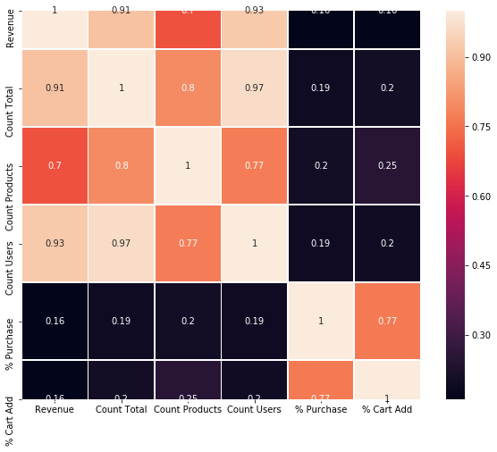

```python
# The correlation matrix let's us see which measures are correlated with each other
# For example we might be interested to see which measures are best correlated with revenue
import matplotlib.pyplot as plt
import seaborn as sn
corrMatrix = Brands[['Revenue','Count Total','Count Products','Count Users','% Purchase','% Cart Add','AVG Price']].corr()
fig, ax = plt.subplots(figsize=(10,8))         # Sample figsize in inches
sn.heatmap(corrMatrix, annot=True, linewidths=.5, ax=ax)
```

# Category Measures

```python
# Same for category overview
NovWithCategory = df_data.dropna(subset=['category_code'])
```

```python
NovWithCategory = NovWithCategory.groupby('category_code')
```

```python
Categories = pd.DataFrame(columns = ['Category', 'Revenue', 'Count Total', '% Purchase', '% Cart Add', 'Count Products', 'Count Users' ,'AVG Price'])
i=0
for category, data in NovWithCategory:
    i+=1
    Categories.loc[i,'Category'] = category
    Categories.loc[i,'Revenue'] = data[data['event_type']=='purchase']['price'].sum()
    Categories.loc[i,'Count Total'] = len(data)
    Categories.loc[i,'% Purchase'] = len(data[data['event_type']=='purchase']) / Brands.loc[i,'Count Total']
    Categories.loc[i,'% Cart Add'] = len(data[data['event_type']=='cart']) / Brands.loc[i,'Count Total']
    Categories.loc[i,'Count Products'] = data['product_id'].nunique()
    Categories.loc[i,'Count Users'] = data['user_id'].nunique()
    Categories.loc[i,'AVG Price'] = data[['product_id','price']].drop_duplicates()['price'].mean()
```

```python
# Print with % style
Categories.style.format({'% Purchase': "{:.2%}",'% Cart Add': "{:.2%}"})
```

|  | Category | Revenue | Count Total | % Purchase | % Cart Add | Count Products | Count Users | AVG Price |
| --- | --- | --- | --- | --- | --- | --- | --- | --- |
| 1 | accessories.bag | 1929.19 | 4938 | 0.29% | 1.64% | 38 | 2014 | 51.0115 |
| 2 | accessories.cosmetic_bag | 233.07 | 693 | 4.12% | 12.95% | 20 | 365 | 4.91654 |
| 3 | apparel.glove | 5174.71 | 8295 | 856.67% | 2776.67% | 95 | 2675 | 6.502 |
| 4 | appliances.environment.air_conditioner | 20.6 | 92 | 0.04% | 0.16% | 16 | 58 | 13.7994 |
| 5 | appliances.environment.vacuum | 22401.7 | 25818 | 5.94% | 27.94% | 85 | 7500 | 46.08 |
| 6 | appliances.personal.hair_cutter | 541.81 | 1102 | 0.34% | 2.56% | 14 | 511 | 33.713 |
| 7 | furniture.bathroom.bath | 2674.75 | 3529 | 83.18% | 322.27% | 58 | 1484 | 15.6308 |
| 8 | furniture.living_room.cabinet | 4625.47 | 4478 | 102.56% | 935.90% | 6 | 2082 | 119.359 |
| 9 | furniture.living_room.chair | 0 | 20 | 0.00% | 0.00% | 2 | 15 | 135.555 |
| 10 | stationery.cartrige | 2230.06 | 9500 | 79.81% | 301.95% | 128 | 2437 | 2.90729 |

```python
# Cast to ints and floats data types
Categories[['Revenue','Count Total','Count Products','Count Users']]=Categories[['Revenue','Count Total','Count Products','Count Users']].astype('int')

Categories[['% Purchase','% Cart Add','AVG Price']]=Categories[['% Purchase','% Cart Add','AVG Price']].astype('float')

Categories.info()
```

```
<class 'pandas.core.frame.DataFrame'>
Int64Index: 10 entries, 1 to 10
Data columns (total 8 columns):
Category          10 non-null object
Revenue           10 non-null int32
Count Total       10 non-null int32
% Purchase        10 non-null float64
% Cart Add        10 non-null float64
Count Products    10 non-null int32
Count Users       10 non-null int32
AVG Price         10 non-null float64
dtypes: float64(3), int32(4), object(1)
memory usage: 880.0+ bytes
```

Correlation Matrix

```python
Categories[['Revenue','Count Total','Count Products','Count Users','% Purchase','% Cart Add','AVG Price']].corr()
```

|  | Revenue | Count Total | Count Products | Count Users | % Purchase | % Cart Add | AVG Price |
| --- | --- | --- | --- | --- | --- | --- | --- |
| Revenue | 1.000000 | 0.957197 | 0.421743 | 0.965874 | 0.058054 | 0.064509 | 0.025498 |
| Count Total | 0.957197 | 1.000000 | 0.641530 | 0.989870 | 0.116437 | 0.104104 | -0.105913 |
| Count Products | 0.421743 | 0.641530 | 1.000000 | 0.591615 | 0.438077 | 0.372036 | -0.551884 |
| Count Users | 0.965874 | 0.989870 | 0.591615 | 1.000000 | 0.133727 | 0.139842 | -0.058765 |
| % Purchase | 0.058054 | 0.116437 | 0.438077 | 0.133727 | 1.000000 | 0.976529 | -0.254936 |
| % Cart Add | 0.064509 | 0.104104 | 0.372036 | 0.139842 | 0.976529 | 1.000000 | -0.135814 |
| AVG Price | 0.025498 | -0.105913 | -0.551884 | -0.058765 | -0.254936 | -0.135814 | 1.000000 |

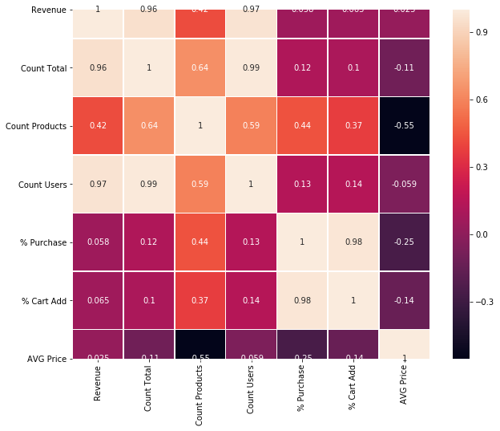

```python
import matplotlib.pyplot as plt
import seaborn as sn
corrMatrix = Categories[['Revenue','Count Total','Count Products','Count Users','% Purchase','% Cart Add','AVG Price']].corr()
fig, ax = plt.subplots(figsize=(10,8))         # Sample figsize in inches
sn.heatmap(corrMatrix, annot=True, linewidths=.5, ax=ax)
```

```python
#Take One Basket
BasketIdSession1 = df_data.loc[(df_data['user_session']== '4b8377a1-cb36-43f9-8551-f27f2a1214a9' )]
```

```python
BasketIdSession1
```

|  | event_time | event_type | product_id | category_id | category_code | brand | price | user_id | user_session |
| --- | --- | --- | --- | --- | --- | --- | --- | --- | --- |
| 107508 | 2019-12-01 19:52:43 UTC | cart | 5729864 | 1487580006509970331 | NaN | NaN | 0.41 | 575709540 | 4b8377a1-cb36-43f9-8551-f27f2a1214a9 |
| 107557 | 2019-12-01 19:53:01 UTC | cart | 5809912 | 1602943681873052386 | NaN | grattol | 5.24 | 575709540 | 4b8377a1-cb36-43f9-8551-f27f2a1214a9 |
| 107568 | 2019-12-01 19:53:07 UTC | cart | 5809911 | 1602943681873052386 | NaN | grattol | 5.24 | 575709540 | 4b8377a1-cb36-43f9-8551-f27f2a1214a9 |
| 108545 | 2019-12-01 19:59:30 UTC | cart | 5727536 | 1487580004882580302 | NaN | NaN | 2.70 | 575709540 | 4b8377a1-cb36-43f9-8551-f27f2a1214a9 |
| 108553 | 2019-12-01 19:59:31 UTC | cart | 5727535 | 1487580004882580302 | NaN | NaN | 2.70 | 575709540 | 4b8377a1-cb36-43f9-8551-f27f2a1214a9 |
| ... | ... | ... | ... | ... | ... | ... | ... | ... | ... |
| 125037 | 2019-12-01 22:32:16 UTC | cart | 5836519 | 2151191071118328683 | NaN | nagaraku | 2.38 | 575709540 | 4b8377a1-cb36-43f9-8551-f27f2a1214a9 |
| 125044 | 2019-12-01 22:32:21 UTC | cart | 5881456 | 2151191071118328683 | NaN | lovely | 3.79 | 575709540 | 4b8377a1-cb36-43f9-8551-f27f2a1214a9 |
| 125075 | 2019-12-01 22:32:52 UTC | cart | 5843301 | 1487580008246412266 | NaN | NaN | 11.27 | 575709540 | 4b8377a1-cb36-43f9-8551-f27f2a1214a9 |
| 125144 | 2019-12-01 22:34:40 UTC | cart | 5894233 | 2151191059751764547 | NaN | cristalinas | 4.75 | 575709540 | 4b8377a1-cb36-43f9-8551-f27f2a1214a9 |
| 125147 | 2019-12-01 22:34:43 UTC | cart | 5894232 | 2151191059751764547 | NaN | cristalinas | 4.75 | 575709540 | 4b8377a1-cb36-43f9-8551-f27f2a1214a9 |

355 rows × 9 columns

```python
#Split the Dataset

interactions_train_df, interactions_test_df = train_test_split(RemovedItem,
                                   stratify=(RemovedItem['product_id'])& (RemovedItem['event_type']) ,
                                   test_size=0.20,
                                   random_state=42)


print('# interactions on Train set: %d' % len(interactions_train_df))
print('# interactions on Test set: %d' % len(interactions_test_df))
```

[output not shown]

```python
#Removed Item From The Cart
AddAndPurshaseItem = BasketIdSession.loc[(BasketIdSession['event_type']== 'remove_from_cart' )]
```

[output not shown]

```python
AddAndPurshaseItem.head(60)
```

[output not shown]

```python
#Take Another Basket
BasketIdSession2 = df_data.loc[(df_data['user_session']== '29b2e9dc-922a-40b6-99d0-77cc925caed3' )]
```

```python
BasketIdSession2
```

|  | event_time | event_type | product_id | category_id | category_code | brand | price | user_id | user_session |
| --- | --- | --- | --- | --- | --- | --- | --- | --- | --- |
| 2162307 | 2019-12-17 13:09:27 UTC | cart | 5892542 | 2145935122136826354 | NaN | metzger | 12.54 | 575709540 | 29b2e9dc-922a-40b6-99d0-77cc925caed3 |
| 2162524 | 2019-12-17 13:11:58 UTC | cart | 5713292 | 1487580008070251489 | appliances.personal.hair_cutter | NaN | 52.86 | 575709540 | 29b2e9dc-922a-40b6-99d0-77cc925caed3 |
| 2162716 | 2019-12-17 13:13:57 UTC | view | 5713292 | 1487580008070251489 | appliances.personal.hair_cutter | NaN | 52.86 | 575709540 | 29b2e9dc-922a-40b6-99d0-77cc925caed3 |
| 2162954 | 2019-12-17 13:16:29 UTC | cart | 5891256 | 1487580008112194531 | NaN | metzger | 4.29 | 575709540 | 29b2e9dc-922a-40b6-99d0-77cc925caed3 |
| 2162962 | 2019-12-17 13:16:33 UTC | cart | 5809116 | 1801635223591453292 | NaN | jaguar | 45.27 | 575709540 | 29b2e9dc-922a-40b6-99d0-77cc925caed3 |
| ... | ... | ... | ... | ... | ... | ... | ... | ... | ... |
| 2166450 | 2019-12-17 13:46:22 UTC | purchase | 5878410 | 1791442895991997390 | NaN | NaN | 10.48 | 575709540 | 29b2e9dc-922a-40b6-99d0-77cc925caed3 |
| 2166451 | 2019-12-17 13:46:22 UTC | purchase | 5886429 | 1487580010318397504 | NaN | chi | 11.54 | 575709540 | 29b2e9dc-922a-40b6-99d0-77cc925caed3 |
| 2166452 | 2019-12-17 13:46:22 UTC | purchase | 5892542 | 2145935122136826354 | NaN | metzger | 12.54 | 575709540 | 29b2e9dc-922a-40b6-99d0-77cc925caed3 |
| 2166453 | 2019-12-17 13:46:22 UTC | purchase | 5914104 | 1487580013824835799 | NaN | dewal | 1.16 | 575709540 | 29b2e9dc-922a-40b6-99d0-77cc925caed3 |
| 2166454 | 2019-12-17 13:46:22 UTC | purchase | 6732 | 1487580013027917999 | NaN | NaN | 8.41 | 575709540 | 29b2e9dc-922a-40b6-99d0-77cc925caed3 |

116 rows × 9 columns

```python
options = ['cart', 'purchase']
```

```python
AddAndPurchaseItem = BasketIdSession2.loc[(BasketIdSession2['event_type']== 'cart')|(BasketIdSession2['event_type']== 'purchase' )]
```

```python
AddAndPurchaseItem.head()
```

|  | event_time | event_type | product_id | category_id | category_code | brand | price | user_id | user_session |
| --- | --- | --- | --- | --- | --- | --- | --- | --- | --- |
| 2162307 | 2019-12-17 13:09:27 UTC | cart | 5892542 | 2145935122136826354 | NaN | metzger | 12.54 | 575709540 | 29b2e9dc-922a-40b6-99d0-77cc925caed3 |
| 2162524 | 2019-12-17 13:11:58 UTC | cart | 5713292 | 1487580008070251489 | appliances.personal.hair_cutter | NaN | 52.86 | 575709540 | 29b2e9dc-922a-40b6-99d0-77cc925caed3 |
| 2162954 | 2019-12-17 13:16:29 UTC | cart | 5891256 | 1487580008112194531 | NaN | metzger | 4.29 | 575709540 | 29b2e9dc-922a-40b6-99d0-77cc925caed3 |
| 2162962 | 2019-12-17 13:16:33 UTC | cart | 5809116 | 1801635223591453292 | NaN | jaguar | 45.27 | 575709540 | 29b2e9dc-922a-40b6-99d0-77cc925caed3 |
| 2163022 | 2019-12-17 13:17:11 UTC | cart | 5808976 | 1487580009445982239 | NaN | NaN | 1.43 | 575709540 | 29b2e9dc-922a-40b6-99d0-77cc925caed3 |

```python
AfterRemoveOneItem = AddAndPurchaseItem[AddAndPurchaseItem.product_id != '5892542']
```

```python
AfterRemoveOneItem
```

|  | event_time | event_type | product_id | category_id | category_code | brand | price | user_id | user_session |
| --- | --- | --- | --- | --- | --- | --- | --- | --- | --- |
| 2162307 | 2019-12-17 13:09:27 UTC | cart | 5892542 | 2145935122136826354 | NaN | metzger | 12.54 | 575709540 | 29b2e9dc-922a-40b6-99d0-77cc925caed3 |
| 2162524 | 2019-12-17 13:11:58 UTC | cart | 5713292 | 1487580008070251489 | appliances.personal.hair_cutter | NaN | 52.86 | 575709540 | 29b2e9dc-922a-40b6-99d0-77cc925caed3 |
| 2162954 | 2019-12-17 13:16:29 UTC | cart | 5891256 | 1487580008112194531 | NaN | metzger | 4.29 | 575709540 | 29b2e9dc-922a-40b6-99d0-77cc925caed3 |
| 2162962 | 2019-12-17 13:16:33 UTC | cart | 5809116 | 1801635223591453292 | NaN | jaguar | 45.27 | 575709540 | 29b2e9dc-922a-40b6-99d0-77cc925caed3 |
| 2163022 | 2019-12-17 13:17:11 UTC | cart | 5808976 | 1487580009445982239 | NaN | NaN | 1.43 | 575709540 | 29b2e9dc-922a-40b6-99d0-77cc925caed3 |
| ... | ... | ... | ... | ... | ... | ... | ... | ... | ... |
| 2166450 | 2019-12-17 13:46:22 UTC | purchase | 5878410 | 1791442895991997390 | NaN | NaN | 10.48 | 575709540 | 29b2e9dc-922a-40b6-99d0-77cc925caed3 |
| 2166451 | 2019-12-17 13:46:22 UTC | purchase | 5886429 | 1487580010318397504 | NaN | chi | 11.54 | 575709540 | 29b2e9dc-922a-40b6-99d0-77cc925caed3 |
| 2166452 | 2019-12-17 13:46:22 UTC | purchase | 5892542 | 2145935122136826354 | NaN | metzger | 12.54 | 575709540 | 29b2e9dc-922a-40b6-99d0-77cc925caed3 |
| 2166453 | 2019-12-17 13:46:22 UTC | purchase | 5914104 | 1487580013824835799 | NaN | dewal | 1.16 | 575709540 | 29b2e9dc-922a-40b6-99d0-77cc925caed3 |
| 2166454 | 2019-12-17 13:46:22 UTC | purchase | 6732 | 1487580013027917999 | NaN | NaN | 8.41 | 575709540 | 29b2e9dc-922a-40b6-99d0-77cc925caed3 |

102 rows × 9 columns

```python
table
```

[output not shown]

```python
y = table['Target']
X = table.drop(columns=['Target'])
```

[output not shown]

```python
table
```

[output not shown]

```python
table = pd.pivot_table(AddAndPurchaseItem,index=['user_id'],columns=['product_id','brand'],values='price')
```

```python
table
```

| product_id brand user_id | 5649305 concept | 5650119 concept | 5650146 concept | 5650583 concept | 5676783 estel | 5677466 estel | 5677622 estel | 5677623 estel | 5677936 estel | 5678033 estel | ... | 5827468 estel | 5827469 estel | 5827473 estel | 5857851 levrana | 5886429 chi | 5891256 metzger | 5892542 metzger | 5910469 dewal | 5910473 dewal | 5914104 dewal |
| --- | --- | --- | --- | --- | --- | --- | --- | --- | --- | --- | --- | --- | --- | --- | --- | --- | --- | --- | --- | --- | --- |
| 575709540 | 6.03 | 6.75 | 5.08 | 6.9 | 7.94 | 11.9 | 6.11 | 6.11 | 4.6 | 4.6 | ... | 7.94 | 10.63 | 14.29 | 6.35 | 11.54 | 4.29 | 12.54 | 10.17 | 12.37 | 1.16 |

1 rows × 29 columns

```python
table = pd.pivot_table(AddAndPurchaseItem,index=['user_id'],columns=['product_id','brand','event_type','event_time'],values=('price'))
```

```python
table
```

| product_id brand event_type event_time user_id | 5649305 concept cart 2019-12-17 13:34:30 UTC | 5649305 concept purchase 2019-12-17 13:46:22 UTC | 5650119 concept cart 2019-12-17 13:34:36 UTC | 5650119 concept cart 2019-12-17 13:40:46 UTC | 5650119 concept purchase 2019-12-17 13:46:22 UTC | 5650146 concept cart 2019-12-17 13:33:44 UTC | 5650146 concept purchase 2019-12-17 13:46:22 UTC | 5650583 concept cart 2019-12-17 13:31:29 UTC | 5650583 concept cart 2019-12-17 13:40:28 UTC | 5650583 concept purchase 2019-12-17 13:46:22 UTC | ... | 5886429 chi purchase 2019-12-17 13:46:22 UTC | 5891256 metzger cart 2019-12-17 13:16:29 UTC | 5891256 metzger cart 2019-12-17 13:20:25 UTC | 5892542 metzger cart 2019-12-17 13:09:27 UTC | 5892542 metzger purchase 2019-12-17 13:46:22 UTC | 5910469 dewal cart 2019-12-17 13:19:11 UTC | 5910473 dewal cart 2019-12-17 13:19:17 UTC | 5914104 dewal cart 2019-12-17 13:39:52 UTC | 5914104 dewal cart 2019-12-17 13:41:11 UTC | 5914104 dewal purchase 2019-12-17 13:46:22 UTC |
| --- | --- | --- | --- | --- | --- | --- | --- | --- | --- | --- | --- | --- | --- | --- | --- | --- | --- | --- | --- | --- | --- |
| 575709540 | 6.03 | 6.03 | 6.75 | 6.75 | 6.75 | 5.08 | 5.08 | 6.9 | 6.9 | 6.9 | ... | 11.54 | 4.29 | 4.29 | 12.54 | 12.54 | 10.17 | 12.37 | 1.16 | 1.16 | 1.16 |

1 rows × 62 columns

```python
del table[5914104]
```

```python
table
```

| product_id brand event_type event_time user_id | 5649305 concept cart 2019-12-17 13:34:30 UTC | 5649305 concept purchase 2019-12-17 13:46:22 UTC | 5650119 concept cart 2019-12-17 13:34:36 UTC | 5650119 concept cart 2019-12-17 13:40:46 UTC | 5650119 concept purchase 2019-12-17 13:46:22 UTC | 5650146 concept cart 2019-12-17 13:33:44 UTC | 5650146 concept purchase 2019-12-17 13:46:22 UTC | 5650583 concept cart 2019-12-17 13:31:29 UTC | 5650583 concept cart 2019-12-17 13:40:28 UTC | 5650583 concept purchase 2019-12-17 13:46:22 UTC | ... | 5857851 levrana purchase 2019-12-17 13:46:22 UTC | 5886429 chi cart 2019-12-17 13:32:37 UTC | 5886429 chi cart 2019-12-17 13:40:41 UTC | 5886429 chi purchase 2019-12-17 13:46:22 UTC | 5891256 metzger cart 2019-12-17 13:16:29 UTC | 5891256 metzger cart 2019-12-17 13:20:25 UTC | 5892542 metzger cart 2019-12-17 13:09:27 UTC | 5892542 metzger purchase 2019-12-17 13:46:22 UTC | 5910469 dewal cart 2019-12-17 13:19:11 UTC | 5910473 dewal cart 2019-12-17 13:19:17 UTC |
| --- | --- | --- | --- | --- | --- | --- | --- | --- | --- | --- | --- | --- | --- | --- | --- | --- | --- | --- | --- | --- | --- |
| 575709540 | 6.03 | 6.03 | 6.75 | 6.75 | 6.75 | 5.08 | 5.08 | 6.9 | 6.9 | 6.9 | ... | 6.35 | 11.54 | 11.54 | 11.54 | 4.29 | 4.29 | 12.54 | 12.54 | 10.17 | 12.37 |

1 rows × 59 columns

```python
table['Target'].values
```

[output not shown]

[output cut: 8 more lines]

[output not shown]

```python
table
```

| product_id brand event_type event_time user_id | 5649305 concept cart 2019-12-17 13:34:30 UTC | 5649305 concept purchase 2019-12-17 13:46:22 UTC | 5650119 concept cart 2019-12-17 13:34:36 UTC | 5650119 concept cart 2019-12-17 13:40:46 UTC | 5650119 concept purchase 2019-12-17 13:46:22 UTC | 5650146 concept cart 2019-12-17 13:33:44 UTC | 5650146 concept purchase 2019-12-17 13:46:22 UTC | 5650583 concept cart 2019-12-17 13:31:29 UTC | 5650583 concept cart 2019-12-17 13:40:28 UTC | 5650583 concept purchase 2019-12-17 13:46:22 UTC | ... | 5857851 levrana purchase 2019-12-17 13:46:22 UTC | 5886429 chi cart 2019-12-17 13:32:37 UTC | 5886429 chi cart 2019-12-17 13:40:41 UTC | 5886429 chi purchase 2019-12-17 13:46:22 UTC | 5891256 metzger cart 2019-12-17 13:16:29 UTC | 5891256 metzger cart 2019-12-17 13:20:25 UTC | 5892542 metzger cart 2019-12-17 13:09:27 UTC | 5892542 metzger purchase 2019-12-17 13:46:22 UTC | 5910469 dewal cart 2019-12-17 13:19:11 UTC | 5910473 dewal cart 2019-12-17 13:19:17 UTC |
| --- | --- | --- | --- | --- | --- | --- | --- | --- | --- | --- | --- | --- | --- | --- | --- | --- | --- | --- | --- | --- | --- |
| 575709540 | 6.03 | 6.03 | 6.75 | 6.75 | 6.75 | 5.08 | 5.08 | 6.9 | 6.9 | 6.9 | ... | 6.35 | 11.54 | 11.54 | 11.54 | 4.29 | 4.29 | 12.54 | 12.54 | 10.17 | 12.37 |

1 rows × 59 columns

```python
for col in table.columns:
    print(col[0])
    if(col[0]== 5650119):
        table=table.assign(Target=5650119)
```

```
5649305
5649305
5650119
5650119
5650119
5650146
5650146
5650583
5650583
5650583
5676783
5676783
5677466
5677622
5677622
5677622
5677622
5677623
5677623
5677623
5677623
5677936
5678033
5678033
5678033
5678034
5678034
5678034
5697464
5739030
5739030
5739030
5807880
5809089
5809116
5809545
5814871
5814877
5827468
5827468
5827468
5827469
5827469
5827469
5827473
5827473
5827473
5857851
5857851
5857851
5886429
5886429
5886429
5891256
5891256
5892542
5892542
5910469
5910473
```

```python
table
```

| product_id brand event_type event_time user_id | 5649305 concept cart 2019-12-17 13:34:30 UTC | 5649305 concept purchase 2019-12-17 13:46:22 UTC | 5650119 concept cart 2019-12-17 13:34:36 UTC | 5650119 concept cart 2019-12-17 13:40:46 UTC | 5650119 concept purchase 2019-12-17 13:46:22 UTC | 5650146 concept cart 2019-12-17 13:33:44 UTC | 5650146 concept purchase 2019-12-17 13:46:22 UTC | 5650583 concept cart 2019-12-17 13:31:29 UTC | 5650583 concept cart 2019-12-17 13:40:28 UTC | 5650583 concept purchase 2019-12-17 13:46:22 UTC | ... | 5886429 chi cart 2019-12-17 13:32:37 UTC | 5886429 chi cart 2019-12-17 13:40:41 UTC | 5886429 chi purchase 2019-12-17 13:46:22 UTC | 5891256 metzger cart 2019-12-17 13:16:29 UTC | 5891256 metzger cart 2019-12-17 13:20:25 UTC | 5892542 metzger cart 2019-12-17 13:09:27 UTC | 5892542 metzger purchase 2019-12-17 13:46:22 UTC | 5910469 dewal cart 2019-12-17 13:19:11 UTC | 5910473 dewal cart 2019-12-17 13:19:17 UTC | Target |
| --- | --- | --- | --- | --- | --- | --- | --- | --- | --- | --- | --- | --- | --- | --- | --- | --- | --- | --- | --- | --- | --- |
| 575709540 | 6.03 | 6.03 | 6.75 | 6.75 | 6.75 | 5.08 | 5.08 | 6.9 | 6.9 | 6.9 | ... | 11.54 | 11.54 | 11.54 | 4.29 | 4.29 | 12.54 | 12.54 | 10.17 | 12.37 | 5650119 |

1 rows × 60 columns

```python
del table[5649305]
```

```python
for col in table.columns:
    print(col[0])
    if(col[0]== 5914104):
        table=table.assign(Target=5914104)
```

```
5650119
5650119
5650119
5650146
5650146
5650583
5650583
5650583
5676783
5676783
5677466
5677622
5677622
5677622
5677622
5677623
5677623
5677623
5677623
5677936
5678033
5678033
5678033
5678034
5678034
5678034
5697464
5739030
5739030
5739030
5807880
5809089
5809116
5809545
5814871
5814877
5827468
5827468
5827468
5827469
5827469
5827469
5827473
5827473
5827473
5857851
5857851
5857851
5886429
5886429
5886429
5891256
5891256
5892542
5892542
5910469
5910473
Target
```

```python
table
```

| product_id brand event_type event_time user_id | 5650119 concept cart 2019-12-17 13:34:36 UTC | 5650119 concept cart 2019-12-17 13:40:46 UTC | 5650119 concept purchase 2019-12-17 13:46:22 UTC | 5650146 concept cart 2019-12-17 13:33:44 UTC | 5650146 concept purchase 2019-12-17 13:46:22 UTC | 5650583 concept cart 2019-12-17 13:31:29 UTC | 5650583 concept cart 2019-12-17 13:40:28 UTC | 5650583 concept purchase 2019-12-17 13:46:22 UTC | 5676783 estel cart 2019-12-17 13:33:49 UTC | 5676783 estel purchase 2019-12-17 13:46:22 UTC | ... | 5886429 chi cart 2019-12-17 13:32:37 UTC | 5886429 chi cart 2019-12-17 13:40:41 UTC | 5886429 chi purchase 2019-12-17 13:46:22 UTC | 5891256 metzger cart 2019-12-17 13:16:29 UTC | 5891256 metzger cart 2019-12-17 13:20:25 UTC | 5892542 metzger cart 2019-12-17 13:09:27 UTC | 5892542 metzger purchase 2019-12-17 13:46:22 UTC | 5910469 dewal cart 2019-12-17 13:19:11 UTC | 5910473 dewal cart 2019-12-17 13:19:17 UTC | Target |
| --- | --- | --- | --- | --- | --- | --- | --- | --- | --- | --- | --- | --- | --- | --- | --- | --- | --- | --- | --- | --- | --- |
| 575709540 | 6.75 | 6.75 | 6.75 | 5.08 | 5.08 | 6.9 | 6.9 | 6.9 | 7.94 | 7.94 | ... | 11.54 | 11.54 | 11.54 | 4.29 | 4.29 | 12.54 | 12.54 | 10.17 | 12.37 | 5650119 |

1 rows × 58 columns

```python
y = table['Target']
X = table.drop(columns=['Target'])
```

```python
table['Target'] = [5910473]
```

```python
table
```

| product_id brand event_type event_time user_id | 5650119 concept cart 2019-12-17 13:34:36 UTC | 5650119 concept cart 2019-12-17 13:40:46 UTC | 5650119 concept purchase 2019-12-17 13:46:22 UTC | 5650146 concept cart 2019-12-17 13:33:44 UTC | 5650146 concept purchase 2019-12-17 13:46:22 UTC | 5650583 concept cart 2019-12-17 13:31:29 UTC | 5650583 concept cart 2019-12-17 13:40:28 UTC | 5650583 concept purchase 2019-12-17 13:46:22 UTC | 5676783 estel cart 2019-12-17 13:33:49 UTC | 5676783 estel purchase 2019-12-17 13:46:22 UTC | ... | 5886429 chi cart 2019-12-17 13:32:37 UTC | 5886429 chi cart 2019-12-17 13:40:41 UTC | 5886429 chi purchase 2019-12-17 13:46:22 UTC | 5891256 metzger cart 2019-12-17 13:16:29 UTC | 5891256 metzger cart 2019-12-17 13:20:25 UTC | 5892542 metzger cart 2019-12-17 13:09:27 UTC | 5892542 metzger purchase 2019-12-17 13:46:22 UTC | 5910469 dewal cart 2019-12-17 13:19:11 UTC | 5910473 dewal cart 2019-12-17 13:19:17 UTC | Target |
| --- | --- | --- | --- | --- | --- | --- | --- | --- | --- | --- | --- | --- | --- | --- | --- | --- | --- | --- | --- | --- | --- |
| 575709540 | 6.75 | 6.75 | 6.75 | 5.08 | 5.08 | 6.9 | 6.9 | 6.9 | 7.94 | 7.94 | ... | 11.54 | 11.54 | 11.54 | 4.29 | 4.29 | 12.54 | 12.54 | 10.17 | 12.37 | 5910473 |

1 rows × 58 columns

# Split The Data

```python
X_train, X_test, y_train, y_test = train_test_split(table['Target'].values,table['user_id'].values,test_size = 0.2,random_state=43)
```

[output not shown]

[output cut: 12 more lines]

[output not shown]

```python
print(y)
```

```
user_id
575709540    5650119
Name: Target, dtype: int64
```

# Train the model

```python
from xgboost import XGBClassifier
model = XGBClassifier(learning_rate=0.1)
model.fit(X_train, y_train)
y_pred = model.predict(X_test)
```

```
---------------------------------------------------------------------------
NameError                                 Traceback (most recent call last)
<ipython-input-36-5d73ae4e28b4> in <module>
      1 from xgboost import XGBClassifier
      2 model = XGBClassifier(learning_rate=0.1)
----> 3 model.fit(X_train, y_train)
      4 y_pred = model.predict(X_test)

NameError: name 'X_train' is not defined
```

```python
from sklearn.linear_model import ElasticNet, Lasso,  BayesianRidge, LassoLarsIC
from sklearn.pipeline import make_pipeline
from sklearn.preprocessing import RobustScaler
```

```python
y.head()
```

```
user_id
575709540    5650119
Name: Target, dtype: int64
```

```python
X_train, X_test, y_train, y_test = train_test_split(X, y,test_size = 0.2,random_state = 0)
sc_X = StandardScaler()
X_train = sc_X.fit_transform(X_train)
X_test = sc_X.transform(X_test)
classifier=AdaBoostClassifier(random_state=0)
classifier.fit(X_train,y_train)
y_pred=classifier.predict(X_test)
acc=accuracy_score(y_test, y_pred)
print(acc)
```

[output not shown]

```python
from sklearn.ensemble import AdaBoostClassifier
ac = table
ac.head()
```

| product_id brand event_type event_time user_id | 5650119 concept cart 2019-12-17 13:34:36 UTC | 5650119 concept cart 2019-12-17 13:40:46 UTC | 5650119 concept purchase 2019-12-17 13:46:22 UTC | 5650146 concept cart 2019-12-17 13:33:44 UTC | 5650146 concept purchase 2019-12-17 13:46:22 UTC | 5650583 concept cart 2019-12-17 13:31:29 UTC | 5650583 concept cart 2019-12-17 13:40:28 UTC | 5650583 concept purchase 2019-12-17 13:46:22 UTC | 5676783 estel cart 2019-12-17 13:33:49 UTC | 5676783 estel purchase 2019-12-17 13:46:22 UTC | ... | 5886429 chi cart 2019-12-17 13:32:37 UTC | 5886429 chi cart 2019-12-17 13:40:41 UTC | 5886429 chi purchase 2019-12-17 13:46:22 UTC | 5891256 metzger cart 2019-12-17 13:16:29 UTC | 5891256 metzger cart 2019-12-17 13:20:25 UTC | 5892542 metzger cart 2019-12-17 13:09:27 UTC | 5892542 metzger purchase 2019-12-17 13:46:22 UTC | 5910469 dewal cart 2019-12-17 13:19:11 UTC | 5910473 dewal cart 2019-12-17 13:19:17 UTC | Target |
| --- | --- | --- | --- | --- | --- | --- | --- | --- | --- | --- | --- | --- | --- | --- | --- | --- | --- | --- | --- | --- | --- |
| 575709540 | 6.75 | 6.75 | 6.75 | 5.08 | 5.08 | 6.9 | 6.9 | 6.9 | 7.94 | 7.94 | ... | 11.54 | 11.54 | 11.54 | 4.29 | 4.29 | 12.54 | 12.54 | 10.17 | 12.37 | 5910473 |

1 rows × 58 columns

```python
#Data is used the same as LGB
X1 = df_data.drop(columns=['price'])
y1 = df_data['price']
```

```python
X_train, X_test, y_train, y_test = train_test_split(X, y,test_size = 0.2,random_state = 42)
#sc_X = Sta>yyform(X_test)
classifier=AdaBoostClassifier(random_state=0)
classifier.fit(X_train,y_train)
y_pred=classifier.predict(X_test)
acc=accuracy_score(y_test, y_pred)
print(acc)
```

[output not shown]

```python
print(X1)
print(y1)
```

```
                      event_time        event_type  product_id  \
0        2019-12-01 00:00:00 UTC  remove_from_cart     5712790
1        2019-12-01 00:00:00 UTC              view     5764655
2        2019-12-01 00:00:02 UTC              cart        4958
3        2019-12-01 00:00:05 UTC              view     5848413
4        2019-12-01 00:00:07 UTC              view     5824148
...                          ...               ...         ...
3533281  2019-12-31 23:59:39 UTC              view     5683350
3533282  2019-12-31 23:59:46 UTC              view     5888097
3533283  2019-12-31 23:59:51 UTC              view       59975
3533284  2019-12-31 23:59:52 UTC              view     5775982
3533285  2019-12-31 23:59:57 UTC              view     5635090

                 category_id category_code      brand    user_id  \
0        1487580005268456287           NaN      f.o.x  576802932
```

[output cut: 37 more lines]

```python
from sklearn.model_selection import train_test_split
```

```python
X_train,X_test,y_train,y_test=train_test_split(X,y,test_size=0.2,random_state=123)
```

[output not shown]

```python
from sklearn import datasets
# Import train_test_split function
from sklearn.model_selection import train_test_split
#Import scikit-learn metrics module for accuracy calculation
from sklearn import metrics
```

```python
#Data is used the same as LGB
X = table1.drop(columns=['Target'])
y = table1['Target']
```

```
---------------------------------------------------------------------------
NameError                                 Traceback (most recent call last)
<ipython-input-47-0323c9068a3d> in <module>
      1 #Data is used the same as LGB
----> 2 X = table1.drop(columns=['Target'])
      3 y = table1['Target']

NameError: name 'table1' is not defined
```

```python
y = df_data['price']
X = df_data.drop(columns=['price'])
```

```python
# Split dataset into training set and test set
X_train, X_test, y_train, y_test = train_test_split(X, y, test_size=0.3) # 70% training and 30% test
```

```python
# Create adaboost classifer object
abc = AdaBoostClassifier(n_estimators=50,
                         learning_rate=1)
# Train Adaboost Classifer
model = abc.fit(X_train, y_train)

#Predict the response for test dataset
y_pred = model.predict(X_test)
```

[output not shown]

```python
# Model Accuracy, how often is the classifier correct?
print("Accuracy:",metrics.accuracy_score(y_test, y_pred))
```

```python
#Create a DataFrame object
dfObj = pd.DataFrame(table,columns = 'product_id' ,'brand')
```

```python
table1 = pd.pivot_table(AddAndPurchaseItem,columns=['product_id','brand','event_type','event_time'])
```

```python
from sklearn.preprocessing import LabelEncoder
from sklearn.preprocessing import MinMaxScaler
from sklearn.model_selection import train_test_split
from xgboost import plot_importance
from sklearn.utils import resample
from sklearn import metrics
```

```python
table1
```

```
             product_id  brand    event_type  event_time
category_id  5649305     concept  cart        2019-12-17 13:34:30 UTC    1.487580e+18
                                  purchase    2019-12-17 13:46:22 UTC    1.487580e+18
             5650119     concept  cart        2019-12-17 13:34:36 UTC    1.487580e+18
                                              2019-12-17 13:40:46 UTC    1.487580e+18
                                  purchase    2019-12-17 13:46:22 UTC    1.487580e+18
                                                                             ...
user_id      5910469     dewal    cart        2019-12-17 13:19:11 UTC    5.757095e+08
             5910473     dewal    cart        2019-12-17 13:19:17 UTC    5.757095e+08
             5914104     dewal    cart        2019-12-17 13:39:52 UTC    5.757095e+08
                                              2019-12-17 13:41:11 UTC    5.757095e+08
                                  purchase    2019-12-17 13:46:22 UTC    5.757095e+08
Length: 186, dtype: float64
```

```python
table1['T'] = [5914104,5910473,5910469,5892542]
```

```python
table1
```

```
             product_id  brand    event_type  event_time
category_id  5649305     concept  cart        2019-12-17 13:34:30 UTC                             1.48758e+18
                                  purchase    2019-12-17 13:46:22 UTC                             1.48758e+18
             5650119     concept  cart        2019-12-17 13:34:36 UTC                             1.48758e+18
                                              2019-12-17 13:40:46 UTC                             1.48758e+18
                                  purchase    2019-12-17 13:46:22 UTC                             1.48758e+18
                                                                                         ...
user_id      5910473     dewal    cart        2019-12-17 13:19:17 UTC                              5.7571e+08
             5914104     dewal    cart        2019-12-17 13:39:52 UTC                              5.7571e+08
                                              2019-12-17 13:41:11 UTC                              5.7571e+08
                                  purchase    2019-12-17 13:46:22 UTC                              5.7571e+08
T                                                                        [5914104, 5910473, 5910469, 5892542]
Length: 187, dtype: object
```

```python
table1['Target']
```

[output not shown]

```python
table1
```

```
             product_id  brand    event_type  event_time
category_id  5649305     concept  cart        2019-12-17 13:34:30 UTC                             1.48758e+18
                                  purchase    2019-12-17 13:46:22 UTC                             1.48758e+18
             5650119     concept  cart        2019-12-17 13:34:36 UTC                             1.48758e+18
                                              2019-12-17 13:40:46 UTC                             1.48758e+18
                                  purchase    2019-12-17 13:46:22 UTC                             1.48758e+18
                                                                                         ...
user_id      5910473     dewal    cart        2019-12-17 13:19:17 UTC                              5.7571e+08
             5914104     dewal    cart        2019-12-17 13:39:52 UTC                              5.7571e+08
                                              2019-12-17 13:41:11 UTC                              5.7571e+08
                                  purchase    2019-12-17 13:46:22 UTC                              5.7571e+08
T                                                                        [5914104, 5910473, 5910469, 5892542]
Length: 187, dtype: object
```